```r
testZeroInflation(simres, plot = FALSE)
```

```
##
##  DHARMa zero-inflation test via comparison to expected zeros with
##  simulation under H0 = fitted model
##
## data:  simulationOutput
## ratioObsSim = 1.101, p-value = 0.744
## alternative hypothesis: two.sided
```

```r
Topmodeltotal1 <- tidy(glmm_mudshal3_nb_total)

tab_df(Topmodeltotal1, file='./04_outputs/Topmodeltotal1.doc')
```

| effect | component | group | term | estimate | std.error | statistic | p.value |
| --- | --- | --- | --- | --- | --- | --- | --- |
| fixed | cond | NA | (Intercept) | 1.76 | 0.60 | 2.95 | 0.00 |
| fixed | cond | NA | todpm | -0.49 | 0.29 | -1.68 | 0.09 |
| fixed | cond | NA | avgmudshal | 0.39 | 0.12 | 3.19 | 0.00 |
| fixed | cond | NA | Mudshal.c | 0.37 | 0.20 | 1.85 | 0.06 |
| ran_pars | cond | Site | sd__(Intercept) | 0.69 | NA | NA | NA |
| ran_pars | cond | month | sd__(Intercept) | 0.66 | NA | NA | NA |
| ran_pars | cond | siteMonth | sd__(Intercept) | 0.64 | NA | NA | NA |

```r
write.csv(Topmodeltotal1, './04_outputs/Topmodeltotal1.csv')

r.squaredGLMM(glmm_mudshal1_nb_total)
```

```
##                 R2m       R2c
## delta     0.2720844 0.6592186
## lognormal 0.3111367 0.7538364
## trigamma  0.2068033 0.5010525
```

```r
car::Anova(glmm_mudshal1_nb_total)
```

```
## Analysis of Deviance Table (Type II Wald chisquare tests)
##
## Response: shoreabun
##             Chisq Df Pr(>Chisq)
## tod        2.4345  1   0.118688
## avgmudshal 9.7511  1   0.001792 **
## ---
## Signif. codes:  0 '***' 0.001 '**' 0.01 '*' 0.05 '.' 0.1 ' ' 1
```

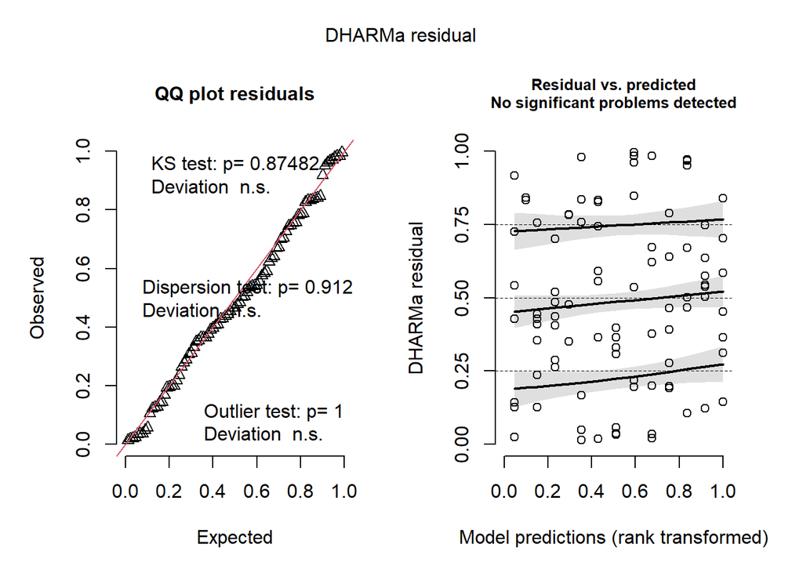

```r
plot(simres <- simulateResiduals(glmm_mudshal1_nb_total))
```

```r
testZeroInflation(simres, plot = FALSE)
```

```
##
##  DHARMa zero-inflation test via comparison to expected zeros with
##  simulation under H0 = fitted model
##
## data:  simulationOutput
## ratioObsSim = 1.0856, p-value = 0.816
## alternative hypothesis: two.sided
```

```r
Topmodeltotal2 <- tidy(glmm_mudshal1_nb_total)

tab_df(Topmodeltotal2, file='./04_outputs/Topmodeltotal2.doc')
```

| effect | component | group | term | estimate | std.error | statistic | p.value |
| --- | --- | --- | --- | --- | --- | --- | --- |
| fixed | cond | NA | (Intercept) | 1.78 | 0.62 | 2.85 | 0.00 |
| fixed | cond | NA | todpm | -0.46 | 0.30 | -1.56 | 0.12 |
| fixed | cond | NA | avgmudshal | 0.39 | 0.13 | 3.12 | 0.00 |
| ran_pars | cond | Site | sd__(Intercept) | 0.70 | NA | NA | NA |
| ran_pars | cond | month | sd__(Intercept) | 0.74 | NA | NA | NA |
| ran_pars | cond | siteMonth | sd__(Intercept) | 0.72 | NA | NA | NA |

```r
write.csv(Topmodeltotal2, './04_outputs/Topmodeltotal2.csv')

r.squaredGLMM(glmm_mudshalwind_nb_total)
```

```
##                 R2m       R2c
## delta     0.2815102 0.6846139
## lognormal 0.3171888 0.7713819
## trigamma  0.2211044 0.5377110
```

```r
car::Anova(glmm_mudshalwind_nb_total)
```

```
## Analysis of Deviance Table (Type II Wald chisquare tests)
##
## Response: shoreabun
##                Chisq Df Pr(>Chisq)
## tod           1.5515  1   0.212909
## avgmudshal    9.5910  1   0.001955 **
## Winddirection 2.0011  1   0.157183
## ---
## Signif. codes:  0 '***' 0.001 '**' 0.01 '*' 0.05 '.' 0.1 ' ' 1
```

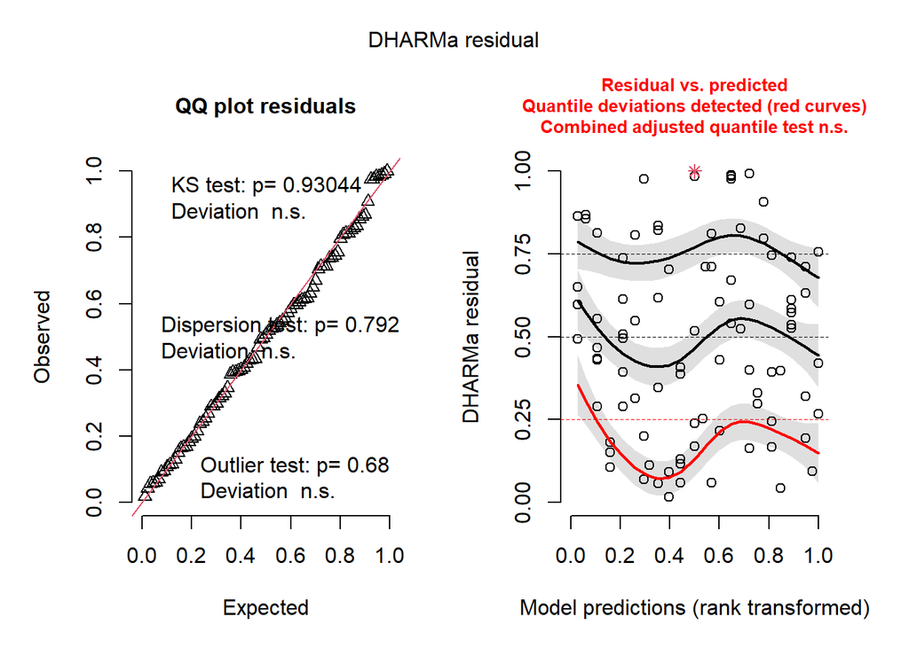

```r
plot(simres <- simulateResiduals(glmm_mudshalwind_nb_total))
```

```r
testZeroInflation(simres, plot = FALSE)
```

```
##
##  DHARMa zero-inflation test via comparison to expected zeros with
##  simulation under H0 = fitted model
##
## data:  simulationOutput
## ratioObsSim = 1.1038, p-value = 0.816
## alternative hypothesis: two.sided
```

```r
Topmodeltotal3 <- tidy(glmm_mudshalwind_nb_total)

tab_df(Topmodeltotal3, file='./04_outputs/Topmodeltotal3.doc')
```

| effect | component | group | term | estimate | std.error | statistic | p.value |
| --- | --- | --- | --- | --- | --- | --- | --- |
| fixed | cond | NA | (Intercept) | 2.10 | 0.67 | 3.12 | 0.00 |
| fixed | cond | NA | todpm | -0.37 | 0.29 | -1.25 | 0.21 |
| fixed | cond | NA | avgmudshal | 0.39 | 0.13 | 3.10 | 0.00 |
| fixed | cond | NA | WinddirectionOth | -0.60 | 0.42 | -1.41 | 0.16 |
| ran_pars | cond | Site | sd__(Intercept) | 0.71 | NA | NA | NA |
| ran_pars | cond | month | sd__(Intercept) | 0.78 | NA | NA | NA |
| ran_pars | cond | siteMonth | sd__(Intercept) | 0.73 | NA | NA | NA |

```r
write.csv(Topmodeltotal3, './04_outputs/Topmodeltotal3.csv')
```

Model site-level Red-necked Stint abundance.

Fit the null model and a model with time-of-day as the explanatory variable and check for overdispersion using a Poisson distribution.

```r
glmmnull_poi_REST <- glmmTMB(RedneckedStint ~ 1 + (1|Site) + (1|month) + (1|siteMonth), data = shorecountsprey, family = poisson)
summary(glmmnull_poi_REST)
```

```
##  Family: poisson  ( log )
## Formula:
## RedneckedStint ~ 1 + (1 | Site) + (1 | month) + (1 | siteMonth)
## Data: shorecountsprey
##
##      AIC      BIC   logLik deviance df.resid
##   2840.8   2850.7  -1416.4   2832.8       85
##
## Random effects:
##
## Conditional model:
##  Groups    Name        Variance Std.Dev.
##  Site      (Intercept) 5.289    2.300
##  month     (Intercept) 1.372    1.171
##  siteMonth (Intercept) 5.621    2.371
## Number of obs: 89, groups:  Site, 7; month, 7; siteMonth, 46
##
## Conditional model:
##             Estimate Std. Error z value Pr(>|z|)
## (Intercept)  0.04672    1.09893   0.043    0.966
```

```r
car::Anova(glmmnull_poi_REST)
```

```
## Analysis of Deviance Table (Type II Wald chisquare tests)
##
## Response: RedneckedStint
##      Chisq Df Pr(>Chisq)
```

```r
performance::check_overdispersion(glmmnull_poi_REST)
```

```
## # Overdispersion test
##
##        dispersion ratio =   23.793
##   Pearson's Chi-Squared = 2022.422
##                 p-value =  < 0.001
```

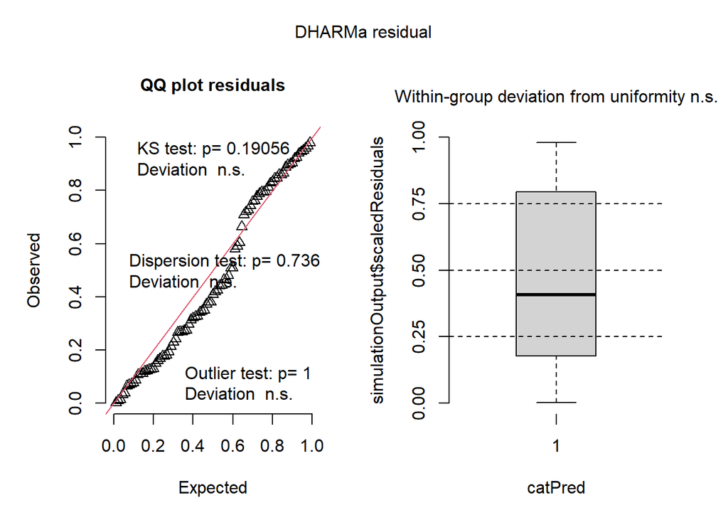

```r
plot(simres <- simulateResiduals(glmmnull_poi_REST))
```

```r
glmmtod_poi_REST <- glmmTMB(RedneckedStint ~ tod + (1|Site) + (1|month) + (1|siteMonth), data = shorecountsprey, family = poisson)
summary(glmmtod_poi_REST)
```

```
##  Family: poisson  ( log )
## Formula:
## RedneckedStint ~ tod + (1 | Site) + (1 | month) + (1 | siteMonth)
## Data: shorecountsprey
##
##      AIC      BIC   logLik deviance df.resid
##   2712.8   2725.2  -1351.4   2702.8       84
##
## Random effects:
##
## Conditional model:
##  Groups    Name        Variance Std.Dev.
##  Site      (Intercept) 5.329    2.309
##  month     (Intercept) 1.372    1.171
##  siteMonth (Intercept) 5.634    2.374
## Number of obs: 89, groups:  Site, 7; month, 7; siteMonth, 46
##
## Conditional model:
##             Estimate Std. Error z value Pr(>|z|)
## (Intercept)  0.20110    1.10189   0.183    0.855
## todpm       -0.37358    0.03306 -11.301   <2e-16 ***
## ---
## Signif. codes:  0 '***' 0.001 '**' 0.01 '*' 0.05 '.' 0.1 ' ' 1
```

```r
car::Anova(glmmtod_poi_REST)
```

```
## Analysis of Deviance Table (Type II Wald chisquare tests)
##
## Response: RedneckedStint
##      Chisq Df Pr(>Chisq)
## tod 127.72  1  < 2.2e-16 ***
## ---
## Signif. codes:  0 '***' 0.001 '**' 0.01 '*' 0.05 '.' 0.1 ' ' 1
```

```r
performance::check_overdispersion(glmmtod_poi_REST)
```

```
## # Overdispersion test
##
##        dispersion ratio =   23.323
##   Pearson's Chi-Squared = 1959.106
##                 p-value =  < 0.001
```

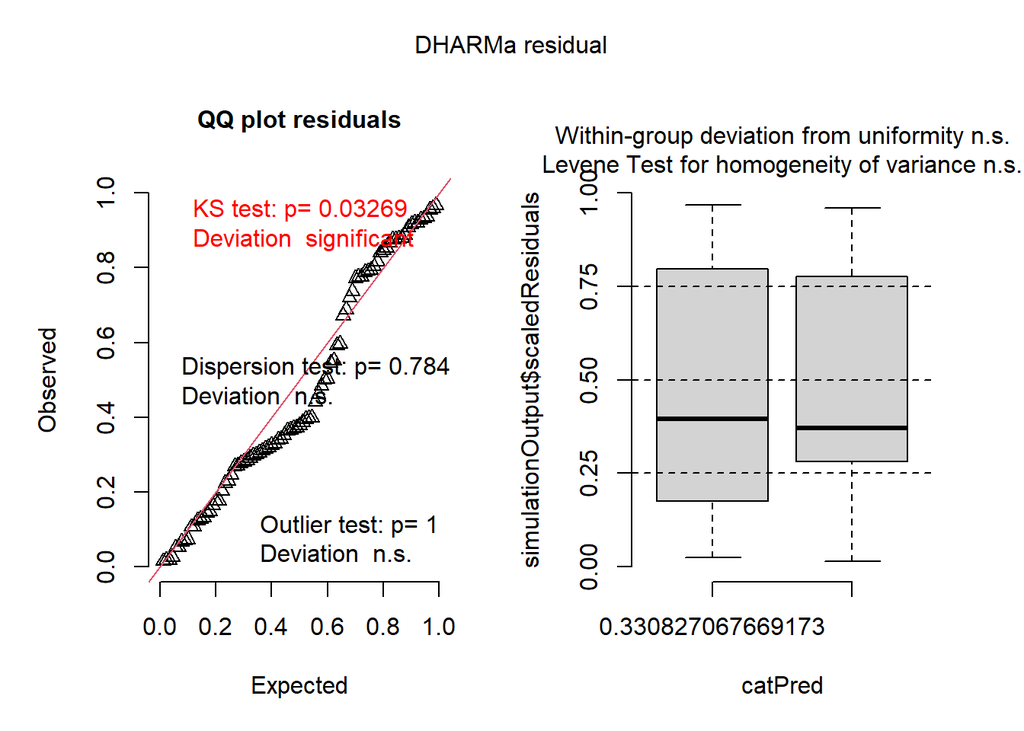

```r
plot(simres <- simulateResiduals(glmmtod_poi_REST))
```

Overdispersed, so use negative binomial distribution instead.

```r
glmmnull_nb_REST <- glmmTMB(RedneckedStint ~ 1 + (1|Site) + (1|month) + (1|siteMonth), data = shorecountsprey, family = 'nbinom2')
summary(glmmnull_nb_REST)
```

```
##  Family: nbinom2  ( log )
## Formula:
## RedneckedStint ~ 1 + (1 | Site) + (1 | month) + (1 | siteMonth)
## Data: shorecountsprey
##
##      AIC      BIC   logLik deviance df.resid
##    520.2    532.7   -255.1    510.2       84
##
## Random effects:
##
## Conditional model:
##  Groups    Name        Variance Std.Dev.
##  Site      (Intercept) 3.794    1.948
##  month     (Intercept) 1.487    1.219
##  siteMonth (Intercept) 1.074    1.036
## Number of obs: 89, groups:  Site, 7; month, 7; siteMonth, 46
##
## Dispersion parameter for nbinom2 family (): 0.199
##
## Conditional model:
##             Estimate Std. Error z value Pr(>|z|)
## (Intercept)    1.754      1.033   1.697   0.0897 .
## ---
## Signif. codes:  0 '***' 0.001 '**' 0.01 '*' 0.05 '.' 0.1 ' ' 1
```

```r
car::Anova(glmmnull_nb_REST)
```

```
## Analysis of Deviance Table (Type II Wald chisquare tests)
##
## Response: RedneckedStint
##      Chisq Df Pr(>Chisq)
```

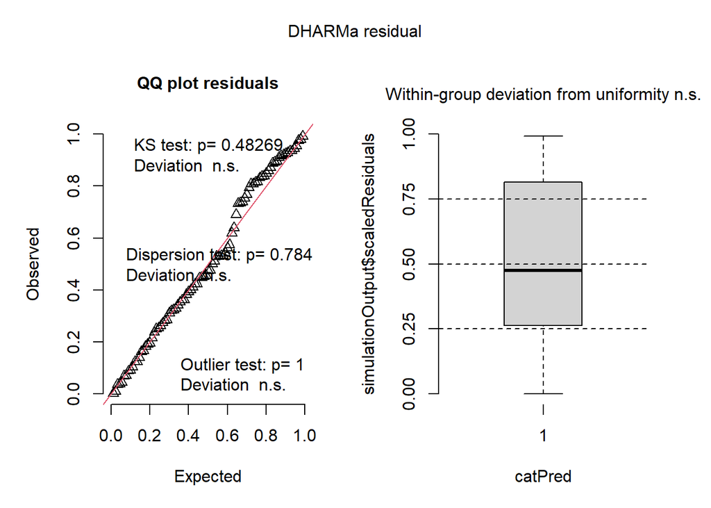

```r
plot(simres <- simulateResiduals(glmmnull_nb_REST))
```

```r
testZeroInflation(simres, plot = FALSE)
```

```
##
##  DHARMa zero-inflation test via comparison to expected zeros with
##  simulation under H0 = fitted model
##
## data:  simulationOutput
## ratioObsSim = 1.0888, p-value = 0.608
## alternative hypothesis: two.sided
```

```r
glmmtod_nb_REST <- glmmTMB(RedneckedStint ~ tod +  (1|Site) + (1|month) + (1|siteMonth), data = shorecountsprey, family = 'nbinom2')
summary(glmmtod_nb_REST)
```

```
##  Family: nbinom2  ( log )
## Formula:
## RedneckedStint ~ tod + (1 | Site) + (1 | month) + (1 | siteMonth)
## Data: shorecountsprey
##
##      AIC      BIC   logLik deviance df.resid
##    520.4    535.3   -254.2    508.4       83
##
## Random effects:
##
## Conditional model:
##  Groups    Name        Variance Std.Dev.
##  Site      (Intercept) 3.994    1.998
##  month     (Intercept) 1.446    1.203
##  siteMonth (Intercept) 1.143    1.069
## Number of obs: 89, groups:  Site, 7; month, 7; siteMonth, 46
##
## Dispersion parameter for nbinom2 family (): 0.211
##
## Conditional model:
##             Estimate Std. Error z value Pr(>|z|)
## (Intercept)   2.0885     1.0817   1.931   0.0535 .
## todpm        -0.8871     0.6484  -1.368   0.1713
## ---
## Signif. codes:  0 '***' 0.001 '**' 0.01 '*' 0.05 '.' 0.1 ' ' 1
```

```r
car::Anova(glmmtod_nb_REST)
```

```
## Analysis of Deviance Table (Type II Wald chisquare tests)
##
## Response: RedneckedStint
##      Chisq Df Pr(>Chisq)
## tod 1.8718  1     0.1713
```

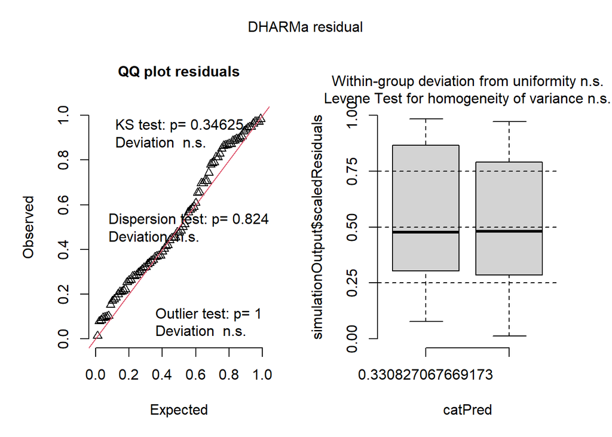

```r
plot(simres <- simulateResiduals(glmmtod_nb_REST))
```

```r
testZeroInflation(simres, plot = FALSE)
```

```
##
##  DHARMa zero-inflation test via comparison to expected zeros with
##  simulation under H0 = fitted model
##
## data:  simulationOutput
## ratioObsSim = 1.0469, p-value = 0.848
## alternative hypothesis: two.sided
```

Model all variables and compare AICs in a table.

```r
glmm_sal_nb_REST <- glmmTMB(RedneckedStint ~ tod + avgsal + (1|Site) + (1|month) + (1|siteMonth), data = shorecountsprey, family = 'nbinom2')

glmm_salC_nb_REST <- glmmTMB(RedneckedStint ~ tod + Salinity.c + (1|Site) + (1|month) + (1|siteMonth), data = shorecountsprey, family = 'nbinom2')

glmm_sal2_nb_REST <- glmmTMB(RedneckedStint ~ tod + avgsal + Salinity.c + (1|Site) + (1|month) + (1|siteMonth), data = shorecountsprey, family = 'nbinom2')

glmm_mudshal1_nb_REST <- glmmTMB(RedneckedStint ~ tod + avgmudshal + (1|Site) + (1|month) + (1|siteMonth), data = shorecountsprey, family = 'nbinom2')

glmm_mudshal2_nb_REST <- glmmTMB(RedneckedStint ~ tod + Mudshal.c + (1|Site) + (1|month) + (1|siteMonth), data = shorecountsprey, family = 'nbinom2')

glmm_mudshal3_nb_REST <- glmmTMB(RedneckedStint ~ tod + avgmudshal + Mudshal.c + (1|Site) + (1|month) + (1|siteMonth), data = shorecountsprey, family = 'nbinom2')

glmm_prey1_nb_REST <- glmmTMB(RedneckedStint ~ tod + avgprey + (1|Site) + (1|month) + (1|siteMonth), data = shorecountsprey, family = 'nbinom2')

glmm_prey2_nb_REST <- glmmTMB(RedneckedStint ~ tod + prey.c + (1|Site) + (1|month) + (1|siteMonth), data = shorecountsprey, family = 'nbinom2')

glmm_prey3_nb_REST <- glmmTMB(RedneckedStint ~ tod + avgprey + prey.c + (1|Site) + (1|month) + (1|siteMonth), data = shorecountsprey, family = 'nbinom2')

glmm_wind1_nb_REST <- glmmTMB(RedneckedStint ~ tod + Winddirection + (1|Site) + (1|month) + (1|siteMonth), data = shorecountsprey, family = 'nbinom2')

glmm_wind2_nb_REST <- glmmTMB(RedneckedStint ~ tod + Windspeed + (1|Site) + (1|month) + (1|siteMonth), data = shorecountsprey, family = 'nbinom2')

glmm_temp_nb_REST <- glmmTMB(RedneckedStint ~ tod + Temperature + (1|Site) + (1|month) + (1|siteMonth), data = shorecountsprey, family = 'nbinom2')

glmm_mudshalwind_nb_REST <- glmmTMB(RedneckedStint ~ tod + avgmudshal + Winddirection + (1|Site) + (1|month) + (1|siteMonth), data = shorecountsprey, family = 'nbinom2')

glmm_mudshalsal_nb_REST <- glmmTMB(RedneckedStint ~ tod + avgmudshal + avgsal + (1|Site) + (1|month) + (1|siteMonth), data = shorecountsprey, family = 'nbinom2')

AICtableREST <-
  AICctab(glmmnull_nb_REST, glmmtod_nb_REST,
        glmm_sal_nb_REST, glmm_salC_nb_REST, glmm_sal2_nb_REST,
        glmm_mudshal1_nb_REST, glmm_mudshal2_nb_REST, glmm_mudshal3_nb_REST,
        glmm_prey1_nb_REST, glmm_prey2_nb_REST, glmm_prey3_nb_REST,
        glmm_wind1_nb_REST, glmm_wind2_nb_REST,
        glmm_temp_nb_REST, glmm_mudshalwind_nb_REST, glmm_mudshalsal_nb_REST,
        base = TRUE, weights = TRUE)

tab_df(AICtableREST, file='./04_outputs/AICtableall_REST.doc')
```

| AICc | dAICc | df | weight |
| --- | --- | --- | --- |
| 514.75 | 0.00 | 8 | 0.50 |
| 517.20 | 2.45 | 7 | 0.15 |
| 517.64 | 2.89 | 8 | 0.12 |
| 519.06 | 4.32 | 7 | 0.06 |
| 519.61 | 4.86 | 8 | 0.04 |
| 520.78 | 6.03 | 7 | 0.02 |
| 520.94 | 6.19 | 7 | 0.02 |
| 520.96 | 6.21 | 5 | 0.02 |
| 521.42 | 6.67 | 6 | 0.02 |
| 522.64 | 7.90 | 8 | 0.01 |
| 522.66 | 7.91 | 7 | 0.01 |
| 522.76 | 8.02 | 7 | 0.01 |
| 523.57 | 8.82 | 7 | 0.01 |
| 523.76 | 9.01 | 7 | 0.01 |
| 523.77 | 9.02 | 7 | 0.01 |
| 525.05 | 10.30 | 8 | 0.00 |

```r
write.csv(AICtableREST, './04_outputs/AICtableall_REST.csv')
```

Check R2 values, variances, residuals and over-dispersion of all top-ranked models (AICc < 2)

```r
r.squaredGLMM(glmm_mudshal3_nb_REST)
```

```
##                 R2m       R2c
## delta     0.3552923 0.6523842
## lognormal 0.4505072 0.8272169
## trigamma  0.1602924 0.2943274
```

```r
car::Anova(glmm_mudshal3_nb_REST)
```

```
## Analysis of Deviance Table (Type II Wald chisquare tests)
##
## Response: RedneckedStint
##             Chisq Df Pr(>Chisq)
## tod        1.2659  1   0.260538
## avgmudshal 9.2283  1   0.002383 **
## Mudshal.c  4.6238  1   0.031531 *
## ---
## Signif. codes:  0 '***' 0.001 '**' 0.01 '*' 0.05 '.' 0.1 ' ' 1
```

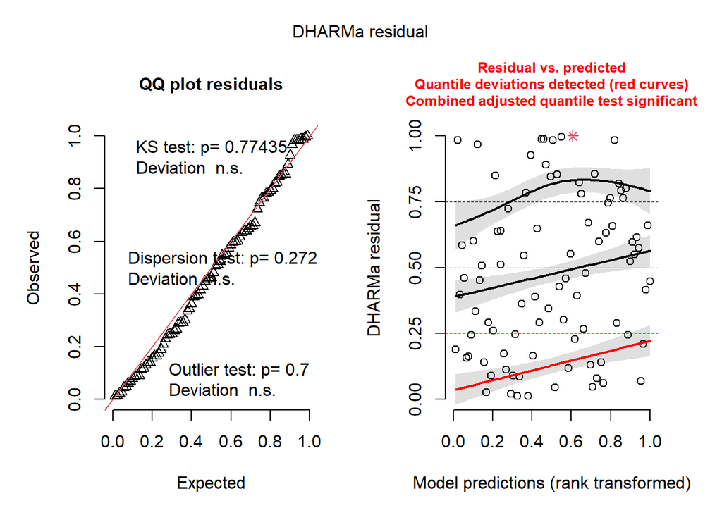

```r
plot(simres <- simulateResiduals(glmm_mudshal3_nb_REST))
```

```r
testZeroInflation(simres, plot = FALSE)
```

```
##
##  DHARMa zero-inflation test via comparison to expected zeros with
##  simulation under H0 = fitted model
##
## data:  simulationOutput
## ratioObsSim = 1.0699, p-value = 0.592
## alternative hypothesis: two.sided
```

```r
TopmodelREST <- tidy(glmm_mudshal3_nb_REST)

tab_df(TopmodelREST, file='./04_outputs/TopmodelREST.doc')
```

| effect | component | group | term | estimate | std.error | statistic | p.value |
| --- | --- | --- | --- | --- | --- | --- | --- |
| fixed | cond | NA | (Intercept) | -0.69 | 1.23 | -0.56 | 0.58 |
| fixed | cond | NA | todpm | -0.69 | 0.61 | -1.13 | 0.26 |
| fixed | cond | NA | avgmudshal | 0.70 | 0.23 | 3.04 | 0.00 |
| fixed | cond | NA | Mudshal.c | 0.91 | 0.42 | 2.15 | 0.03 |
| ran_pars | cond | Site | sd__(Intercept) | 1.10 | NA | NA | NA |
| ran_pars | cond | month | sd__(Intercept) | 1.03 | NA | NA | NA |
| ran_pars | cond | siteMonth | sd__(Intercept) | 1.15 | NA | NA | NA |

```r
write.csv(TopmodelREST, './04_outputs/TopmodelREST.csv')
```

Model site-level Red-capped Plover abundance.

Fit the null model and a model with time-of-day as the explanatory variable and check for overdispersion using a Poisson distribution.

```r
glmmnull_poi_REPL <- glmmTMB(RedcappedPlover ~ 1 + (1|Site) + (1|month) + (1|siteMonth), data = shorecountsprey, family = poisson)
summary(glmmnull_poi_REPL)
```

```
##  Family: poisson  ( log )
## Formula:
## RedcappedPlover ~ 1 + (1 | Site) + (1 | month) + (1 | siteMonth)
## Data: shorecountsprey
##
##      AIC      BIC   logLik deviance df.resid
##    624.6    634.6   -308.3    616.6       85
##
## Random effects:
##
## Conditional model:
##  Groups    Name        Variance Std.Dev.
##  Site      (Intercept) 3.1809   1.7835
##  month     (Intercept) 0.7704   0.8777
##  siteMonth (Intercept) 1.9663   1.4022
## Number of obs: 89, groups:  Site, 7; month, 7; siteMonth, 46
##
## Conditional model:
##             Estimate Std. Error z value Pr(>|z|)
## (Intercept)  -0.1914     0.8189  -0.234    0.815
```

```r
car::Anova(glmmnull_poi_REPL)
```

```
## Analysis of Deviance Table (Type II Wald chisquare tests)
##
## Response: RedcappedPlover
##      Chisq Df Pr(>Chisq)
```

```r
performance::check_overdispersion(glmmnull_poi_REPL)
```

```
## # Overdispersion test
##
##        dispersion ratio =   3.133
##   Pearson's Chi-Squared = 266.306
##                 p-value = < 0.001
```

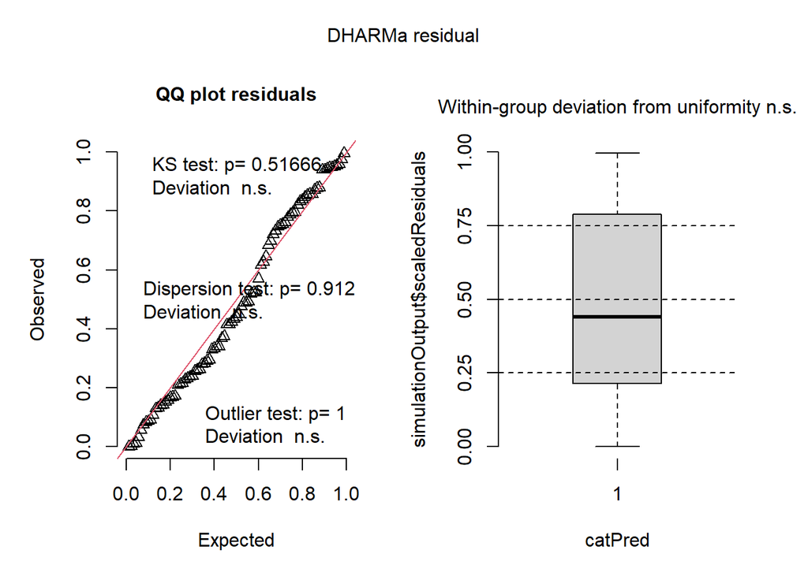

```r
plot(simres <- simulateResiduals(glmmnull_poi_REPL))
```

```r
glmmtod_poi_REPL <- glmmTMB(RedcappedPlover ~ tod + (1|Site) + (1|month) + (1|siteMonth), data = shorecountsprey, family = poisson)
summary(glmmtod_poi_REPL)
```

```
##  Family: poisson  ( log )
## Formula:
## RedcappedPlover ~ tod + (1 | Site) + (1 | month) + (1 | siteMonth)
## Data: shorecountsprey
##
##      AIC      BIC   logLik deviance df.resid
##    594.0    606.4   -292.0    584.0       84
##
## Random effects:
##
## Conditional model:
##  Groups    Name        Variance Std.Dev.
##  Site      (Intercept) 3.2044   1.7901
##  month     (Intercept) 0.7763   0.8811
##  siteMonth (Intercept) 1.9433   1.3940
## Number of obs: 89, groups:  Site, 7; month, 7; siteMonth, 46
##
## Conditional model:
##             Estimate Std. Error z value Pr(>|z|)
## (Intercept) -0.01144    0.82156  -0.014    0.989
## todpm       -0.43393    0.07683  -5.648 1.63e-08 ***
## ---
## Signif. codes:  0 '***' 0.001 '**' 0.01 '*' 0.05 '.' 0.1 ' ' 1
```

```r
car::Anova(glmmtod_poi_REPL)
```

```
## Analysis of Deviance Table (Type II Wald chisquare tests)
##
## Response: RedcappedPlover
##      Chisq Df Pr(>Chisq)
## tod 31.896  1  1.626e-08 ***
## ---
## Signif. codes:  0 '***' 0.001 '**' 0.01 '*' 0.05 '.' 0.1 ' ' 1
```

```r
performance::check_overdispersion(glmmtod_poi_REPL)
```

```
## # Overdispersion test
##
##        dispersion ratio =   2.905
##   Pearson's Chi-Squared = 244.051
##                 p-value = < 0.001
```

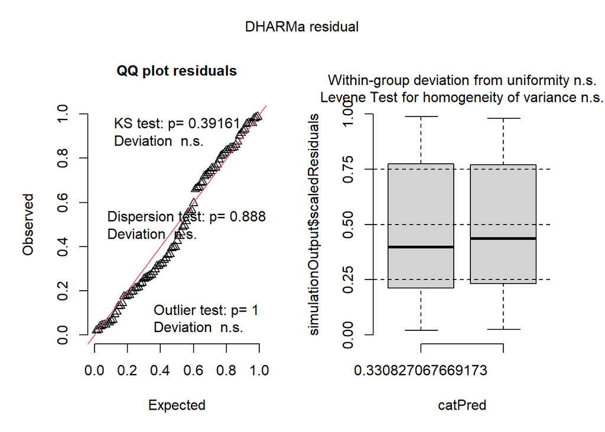

```r
plot(simres <- simulateResiduals(glmmtod_poi_REPL))
```

Overdispersed, so use negative binomial distribution instead.

```r
glmmnull_nb_REPL <- glmmTMB(RedcappedPlover ~ 1 + (1|Site) + (1|month) + (1|siteMonth), data = shorecountsprey, family = 'nbinom2')
summary(glmmnull_nb_REPL)
```

```
##  Family: nbinom2  ( log )
## Formula:
## RedcappedPlover ~ 1 + (1 | Site) + (1 | month) + (1 | siteMonth)
## Data: shorecountsprey
##
##      AIC      BIC   logLik deviance df.resid
##    402.1    414.5   -196.0    392.1       84
##
## Random effects:
##
## Conditional model:
##  Groups    Name        Variance Std.Dev.
##  Site      (Intercept) 3.0942   1.7590
##  month     (Intercept) 0.7895   0.8885
##  siteMonth (Intercept) 0.8751   0.9355
## Number of obs: 89, groups:  Site, 7; month, 7; siteMonth, 46
##
## Dispersion parameter for nbinom2 family (): 0.734
##
## Conditional model:
##             Estimate Std. Error z value Pr(>|z|)
## (Intercept)   0.2356     0.8363   0.282    0.778
```

```r
car::Anova(glmmnull_nb_REPL)
```

```
## Analysis of Deviance Table (Type II Wald chisquare tests)
##
## Response: RedcappedPlover
##      Chisq Df Pr(>Chisq)
```

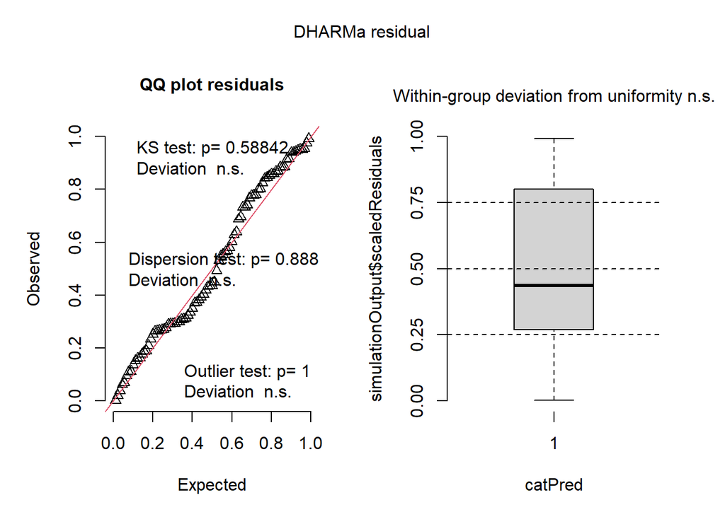

```r
plot(simres <- simulateResiduals(glmmnull_nb_REPL))
```

```r
testZeroInflation(simres, plot = FALSE)
```

```
##
##  DHARMa zero-inflation test via comparison to expected zeros with
##  simulation under H0 = fitted model
##
## data:  simulationOutput
## ratioObsSim = 1.0806, p-value = 0.76
## alternative hypothesis: two.sided
```

```r
glmmtod_nb_REPL <- glmmTMB(RedcappedPlover ~ tod +  (1|Site) + (1|month) + (1|siteMonth), data = shorecountsprey, family = 'nbinom2')
summary(glmmtod_nb_REPL)
```

```
##  Family: nbinom2  ( log )
## Formula:
## RedcappedPlover ~ tod + (1 | Site) + (1 | month) + (1 | siteMonth)
## Data: shorecountsprey
##
##      AIC      BIC   logLik deviance df.resid
##    400.4    415.4   -194.2    388.4       83
##
## Random effects:
##
## Conditional model:
##  Groups    Name        Variance Std.Dev.
##  Site      (Intercept) 3.2027   1.7896
##  month     (Intercept) 0.8564   0.9254
##  siteMonth (Intercept) 0.7674   0.8760
## Number of obs: 89, groups:  Site, 7; month, 7; siteMonth, 46
##
## Dispersion parameter for nbinom2 family (): 0.772
##
## Conditional model:
##             Estimate Std. Error z value Pr(>|z|)
## (Intercept)   0.5359     0.8718   0.615   0.5387
## todpm        -0.6960     0.3719  -1.872   0.0613 .
## ---
## Signif. codes:  0 '***' 0.001 '**' 0.01 '*' 0.05 '.' 0.1 ' ' 1
```

```r
car::Anova(glmmtod_nb_REPL)
```

```
## Analysis of Deviance Table (Type II Wald chisquare tests)
##
## Response: RedcappedPlover
##      Chisq Df Pr(>Chisq)
## tod 3.5028  1    0.06127 .
## ---
## Signif. codes:  0 '***' 0.001 '**' 0.01 '*' 0.05 '.' 0.1 ' ' 1
```

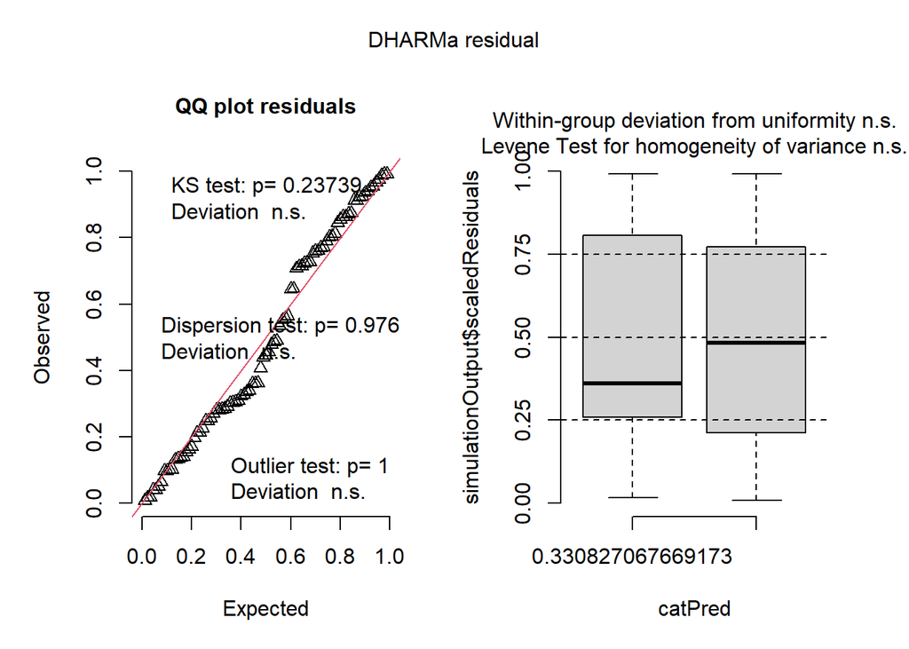

```r
plot(simres <- simulateResiduals(glmmtod_nb_REPL))
```

```r
testZeroInflation(simres, plot = FALSE)
```

```
##
##  DHARMa zero-inflation test via comparison to expected zeros with
##  simulation under H0 = fitted model
##
## data:  simulationOutput
## ratioObsSim = 1.0599, p-value = 0.92
## alternative hypothesis: two.sided
```

Model all variables and compare AICs in a table.

```r
glmm_sal_nb_REPL <- glmmTMB(RedcappedPlover ~ tod + avgsal + (1|Site) + (1|month) + (1|siteMonth), data = shorecountsprey, family = 'nbinom2')

glmm_salC_nb_REPL <- glmmTMB(RedcappedPlover ~ tod + Salinity.c + (1|Site) + (1|month) + (1|siteMonth), data = shorecountsprey, family = 'nbinom2')

glmm_sal2_nb_REPL <- glmmTMB(RedcappedPlover ~ tod + avgsal + Salinity.c + (1|Site) + (1|month) + (1|siteMonth), data = shorecountsprey, family = 'nbinom2')

glmm_mudshal1_nb_REPL <- glmmTMB(RedcappedPlover ~ tod + avgmudshal + (1|Site) + (1|month) + (1|siteMonth), data = shorecountsprey, family = 'nbinom2')

glmm_mudshal2_nb_REPL <- glmmTMB(RedcappedPlover ~ tod + Mudshal.c + (1|Site) + (1|month) + (1|siteMonth), data = shorecountsprey, family = 'nbinom2')

glmm_mudshal3_nb_REPL <- glmmTMB(RedcappedPlover ~ tod + + avgmudshal + Mudshal.c + (1|Site) + (1|month) + (1|siteMonth), data = shorecountsprey, family = 'nbinom2')

glmm_prey1_nb_REPL <- glmmTMB(RedcappedPlover ~ tod + avgprey + (1|Site) + (1|month) + (1|siteMonth), data = shorecountsprey, family = 'nbinom2')

glmm_prey2_nb_REPL <- glmmTMB(RedcappedPlover ~ tod + prey.c + (1|Site) + (1|month) + (1|siteMonth), data = shorecountsprey, family = 'nbinom2')

glmm_prey3_nb_REPL <- glmmTMB(RedcappedPlover ~ tod + avgprey + prey.c + (1|Site) + (1|month) + (1|siteMonth), data = shorecountsprey, family = 'nbinom2')

glmm_wind1_nb_REPL <- glmmTMB(RedcappedPlover ~ tod + Winddirection + (1|Site) + (1|month) + (1|siteMonth), data = shorecountsprey, family = 'nbinom2')

glmm_wind2_nb_REPL <- glmmTMB(RedcappedPlover ~ tod + Windspeed + (1|Site) + (1|month) + (1|siteMonth), data = shorecountsprey, family = 'nbinom2')

glmm_temp_nb_REPL <- glmmTMB(RedcappedPlover ~ tod + Temperature + (1|Site) + (1|month) + (1|siteMonth), data = shorecountsprey, family = 'nbinom2')

glmm_mudshalwind_nb_REPL <- glmmTMB(RedcappedPlover ~ tod + avgmudshal + Winddirection + (1|Site) + (1|month) + (1|siteMonth), data = shorecountsprey, family = 'nbinom2')

glmm_mudshalsal_nb_REPL <- glmmTMB(RedcappedPlover ~ tod + avgmudshal + avgsal + (1|Site) + (1|month) + (1|siteMonth), data = shorecountsprey, family = 'nbinom2')

AICtableREPL <-
  AICctab(glmmnull_nb_REPL, glmmtod_nb_REPL,
        glmm_sal_nb_REPL, glmm_salC_nb_REPL, glmm_sal2_nb_REPL,
        glmm_mudshal1_nb_REPL, glmm_mudshal2_nb_REPL, glmm_mudshal3_nb_REPL,
        glmm_prey1_nb_REPL, glmm_prey2_nb_REPL, glmm_prey3_nb_REPL,
        glmm_wind1_nb_REPL, glmm_wind2_nb_REPL,
        glmm_temp_nb_REPL, glmm_mudshalwind_nb_REPL, glmm_mudshalsal_nb_REPL,
        base = TRUE, weights = TRUE)

tab_df(AICtableREPL, file='./04_outputs/AICtableall_REPL.doc')
```

| AICc | dAICc | df | weight |
| --- | --- | --- | --- |
| 386.83 | 0.00 | 8 | 0.86 |
| 392.30 | 5.47 | 7 | 0.06 |
| 392.41 | 5.58 | 8 | 0.05 |
| 394.63 | 7.79 | 8 | 0.02 |
| 396.49 | 9.66 | 7 | 0.01 |
| 401.00 | 14.16 | 7 | 0.00 |
| 401.44 | 14.60 | 7 | 0.00 |
| 401.47 | 14.64 | 6 | 0.00 |
| 402.82 | 15.99 | 5 | 0.00 |
| 403.13 | 16.29 | 7 | 0.00 |
| 403.20 | 16.37 | 7 | 0.00 |
| 403.41 | 16.58 | 8 | 0.00 |
| 403.67 | 16.84 | 7 | 0.00 |
| 403.75 | 16.91 | 7 | 0.00 |
| 403.83 | 17.00 | 7 | 0.00 |
| 404.91 | 18.07 | 8 | 0.00 |

```r
write.csv(AICtableREPL, './04_outputs/AICtableall_REPL.csv')
```

Check R2 values, variances, residuals and over-dispersion of all top-ranked models (AICc < 2)

```r
r.squaredGLMM(glmm_mudshal3_nb_REPL)
```

```
##                 R2m       R2c
## delta     0.6024966 0.6898137
## lognormal 0.7001875 0.8016626
## trigamma  0.4146758 0.4747729
```

```r
car::Anova(glmm_mudshal3_nb_REPL)
```

```
## Analysis of Deviance Table (Type II Wald chisquare tests)
##
## Response: RedcappedPlover
##              Chisq Df Pr(>Chisq)
## tod         4.0838  1  0.0432967 *
## avgmudshal 27.3317  1  1.714e-07 ***
## Mudshal.c  11.4024  1  0.0007335 ***
## ---
## Signif. codes:  0 '***' 0.001 '**' 0.01 '*' 0.05 '.' 0.1 ' ' 1
```

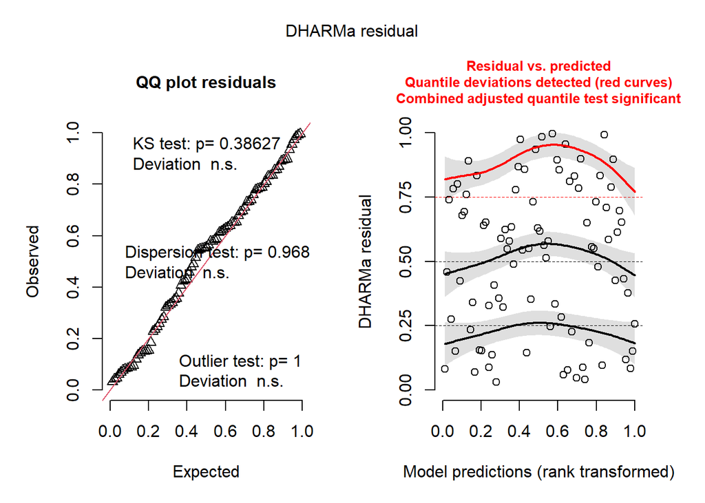

```r
plot(simres <- simulateResiduals(glmm_mudshal3_nb_REPL))
```

```r
testZeroInflation(simres, plot = FALSE)
```

```
##
##  DHARMa zero-inflation test via comparison to expected zeros with
##  simulation under H0 = fitted model
##
## data:  simulationOutput
## ratioObsSim = 1.0248, p-value = 0.912
## alternative hypothesis: two.sided
```

```r
TopmodelREPL <- tidy(glmm_mudshal3_nb_REPL)

tab_df(TopmodelREPL, file='./04_outputs/TopmodelREPL.doc')
```

| effect | component | group | term | estimate | std.error | statistic | p.value |
| --- | --- | --- | --- | --- | --- | --- | --- |
| fixed | cond | NA | (Intercept) | -1.44 | 0.62 | -2.33 | 0.02 |
| fixed | cond | NA | todpm | -0.79 | 0.39 | -2.02 | 0.04 |
| fixed | cond | NA | avgmudshal | 0.66 | 0.13 | 5.23 | 0.00 |
| fixed | cond | NA | Mudshal.c | 0.87 | 0.26 | 3.38 | 0.00 |
| ran_pars | cond | Site | sd__(Intercept) | 0.61 | NA | NA | NA |
| ran_pars | cond | month | sd__(Intercept) | 0.44 | NA | NA | NA |
| ran_pars | cond | siteMonth | sd__(Intercept) | 0.00 | NA | NA | NA |

```r
write.csv(TopmodelREPL, './04_outputs/TopmodelREPL.csv')
```

Obtain and plot predicted values of the top model for Red-necked Stint and Red-capped Plover abundance.

Set up dataframe for predictions. Vary a single parameter while setting the rest at their mean values. Choose a level for factor variables and select a value for any random effect so all variables used for fitting the model are represented.

Retrieve a function to back-convert from the link to the response scale, in this case exp because nbinom has a log link.

Make predictions, on the link scale, setting all random effects to zero, then back-transform.

Plot the responses.

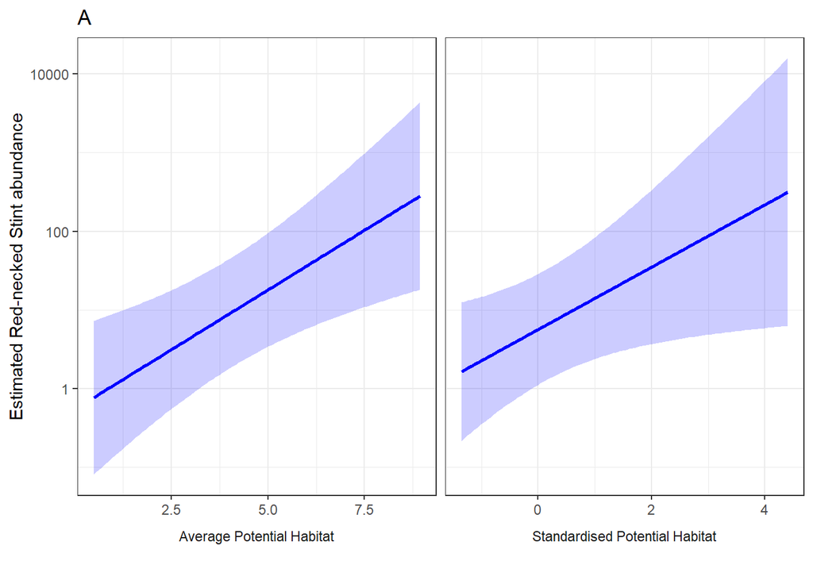

```r
new_data <- data.frame(tod='am', avgmudshal=mean(shorecountsprey$avgmudshal),
                       Mudshal.c=mean(shorecountsprey$Mudshal.c),
                       Site=shorecountsprey$Site[1], month=shorecountsprey$month[1],
                       siteMonth=shorecountsprey$siteMonth[1])
new_data1 <- new_data2 <- new_data[rep(1,100),]
new_data1$avgmudshal <- seq(min(shorecountsprey$avgmudshal), max(shorecountsprey$avgmudshal), length.out=100)
new_data1$x <- new_data1$avgmudshal
new_data1$Variable <- 'Average Potential Habitat'
new_data2$Mudshal.c <- seq(min(shorecountsprey$Mudshal.c), max(shorecountsprey$Mudshal.c), length.out=100)
new_data2$Variable <- 'Standardised Potential Habitat'
new_data2$x <- new_data2$Mudshal.c
new_data <- rbind(new_data1, new_data2)

ilink_REST <- family(glmm_mudshal3_nb_REST)$linkinv

pred_REST <- predict(glmm_mudshal3_nb_REST, new_data, type = "link", se.fit = TRUE, re.form=~0)
pred_REST <- cbind(pred_REST, new_data)

pred_REST <- transform(pred_REST, lwr_ci = ilink_REST(fit - (1.96* se.fit)),
                  upr_ci = ilink_REST(fit + (1.96 * se.fit)),
                  fitted = ilink_REST(fit))

predicted_REST <- ggplot(pred_REST, aes(x, fitted)) +
  geom_ribbon(aes(ymin=lwr_ci, ymax=upr_ci), fill='blue', alpha=0.2, ) +
  geom_line(colour='blue', size=1) +
  scale_y_log10() +
  facet_grid(~Variable, scales='free_x', switch='x') +
  ggtitle("A") +
  xlab('') +
  ylab('Estimated Red-necked Stint abundance') + theme_bw() +
  theme(strip.placement='outside',strip.background = element_blank())

predicted_REST
```

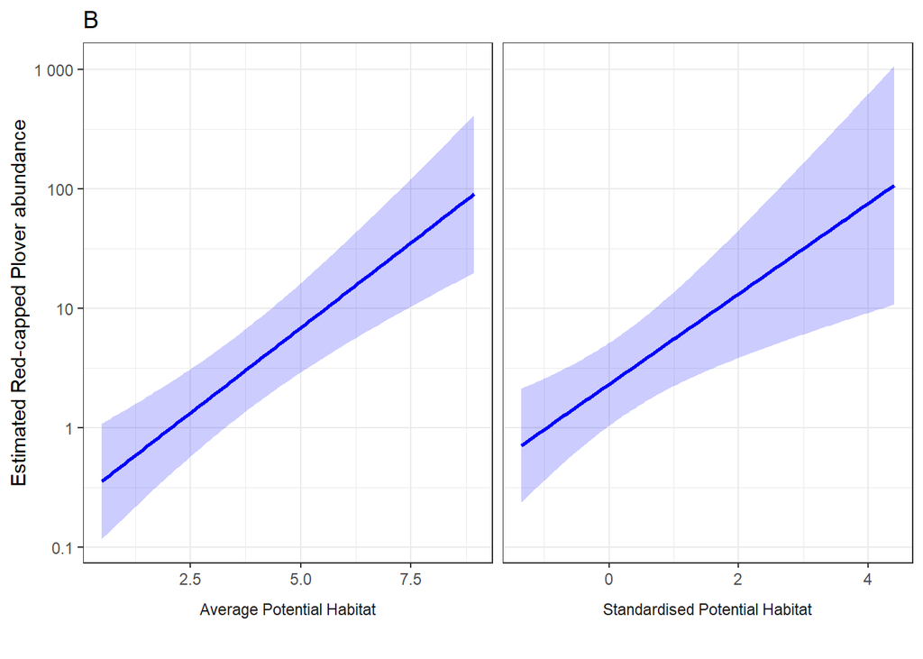

```r
ggsave("./03_plots/predicted_REST.png", plot = predicted_REST, width = 8, height = 5, dpi = 300)

ilink_REPL <- family(glmm_mudshal3_nb_REPL)$linkinv

pred_REPL <- predict(glmm_mudshal3_nb_REPL, new_data, type = "link", se.fit = TRUE, re.form=~0)
pred_REPL <- cbind(pred_REPL, new_data)

pred_REPL <- transform(pred_REPL, lwr_ci = ilink_REPL(fit - (1.96* se.fit)),
                  upr_ci = ilink_REPL(fit + (1.96 * se.fit)),
                  fitted = ilink_REPL(fit))

options(scipen=999)

predicted_REPL <- ggplot(pred_REPL, aes(x, fitted)) +
  geom_ribbon(aes(ymin=lwr_ci, ymax=upr_ci), fill='blue', alpha=0.2, ) +
  geom_line(colour='blue', size=1) +
  scale_y_log10(labels = label_number(drop0trailing = TRUE)) +
  facet_grid(~Variable, scales='free_x', switch='x') +
  ggtitle("B") +
  xlab('') +
  ylab('Estimated Red-capped Plover abundance') + theme_bw() +
  theme(strip.placement='outside',strip.background = element_blank())

predicted_REPL
```

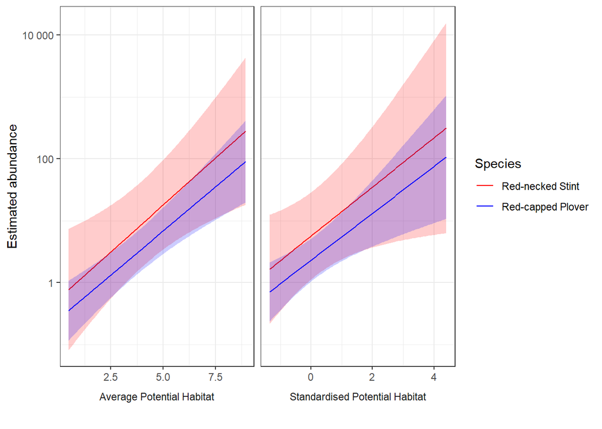

```r
ggsave("./03_plots/predicted_REPL.png", plot = predicted_REPL, width = 8, height = 5, dpi = 300)


predicted_both <- ggplot() +
  geom_line(data = pred_REST, aes(x, fitted, colour='Red-necked Stint')) +
  geom_ribbon(data = pred_REST, aes(x, fitted, ymin=lwr_ci, ymax=upr_ci),
              fill='red', alpha=0.2, ) +
  geom_line(data = pred_REPL, aes(x, fitted, colour='Red-capped Plover')) +
  geom_ribbon(data = pred_REPL, aes(x, fitted, ymin=lwr_ci, ymax=upr_ci),
              fill='blue', alpha=0.2, ) +
  scale_y_log10(labels = label_number(drop0trailing = TRUE)) +
  facet_grid(~Variable, scales='free_x', switch='x') +
  scale_color_manual(name='Species',
                     breaks=c('Red-necked Stint', 'Red-capped Plover'),
                     values=c('Red-necked Stint'='red', 'Red-capped Plover'='blue')) +
  xlab('') +
  ylab('Estimated abundance') + theme_bw() +
  theme(strip.placement='outside',strip.background = element_blank())
predicted_both
```

```r
ggsave("./03_plots/predicted_both.png", plot = predicted_both, width = 8, height = 3.5, dpi = 300)
```

Import and organise shorebird foraging video data:

Filter out high difficulty videos. Add a variable for pecks + probes.

Add column for month and day.

Summarise number of videos by species and site.

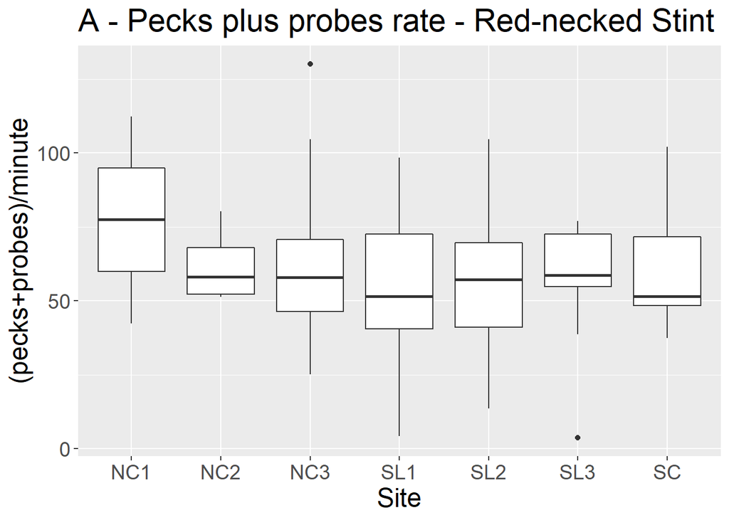

```r
shfor <- read_csv("./01_data/CoorongForagingVideos.csv")

shfor <- shfor %>%
  filter(Difficulty != "High") %>%
  mutate(peckprobe = Pecks + Probes)

shfor <- shfor %>%
  mutate(pprate = (peckprobe/Time_sec)*60,
         steprate = (Steps/Time_sec)*60)

shfor <- shfor %>%
  mutate(Date = as.Date(Date, "%d/%m/%Y")) %>%
  mutate(month = factor(format(Date, "%m"), levels = c('04', '06', '08', '10', '12', '02', '03'))) %>%
  mutate(day = format(Date, "%d"))

foragesumm1 <- shfor %>%
  count(Species)

foragesumm2 <- shfor %>%
  count(Site)

meanrates <- shfor %>%
  select(Species, pprate, steprate) %>%
  group_by(Species) %>%
  summarise(meanpp=mean(pprate),
            meanstep=mean(steprate),
            sdpp=sd(pprate),
            sdstep=sd(steprate))

level_order1 <- c('NC1', 'NC2', 'NC3', 'SL1', 'SL2', 'SL3', 'SC')

RESTfor <- shfor %>%
  filter(Species=="REST")

REPLfor <- shfor %>%
  filter(Species=="REPL")

PPpersite_REST <-
  ggplot(RESTfor, aes(x=factor(Site, level = level_order1), pprate)) +
  labs(x = "Site", y = "(pecks+probes)/minute") +
  theme(text = element_text(size=18)) +
  geom_boxplot() +
  ggtitle("A - Pecks plus probes rate - Red-necked Stint")
PPpersite_REST
```

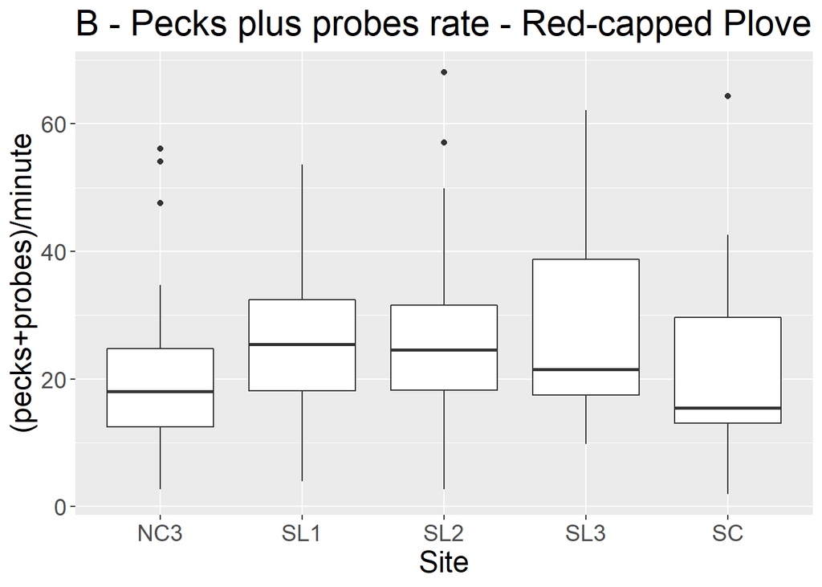

```r
ggsave("./03_plots/PPpersite_REST.png", plot = PPpersite_REST, width = 10, height = 5, dpi = 300)

PPpersite_REPL <-
  ggplot(REPLfor, aes(x=factor(Site, level = level_order1), pprate)) +
  labs(x = "Site", y = "(pecks+probes)/minute") +
  theme(text = element_text(size=18)) +
  geom_boxplot() +
  ggtitle("B - Pecks plus probes rate - Red-capped Plove")
PPpersite_REPL
```

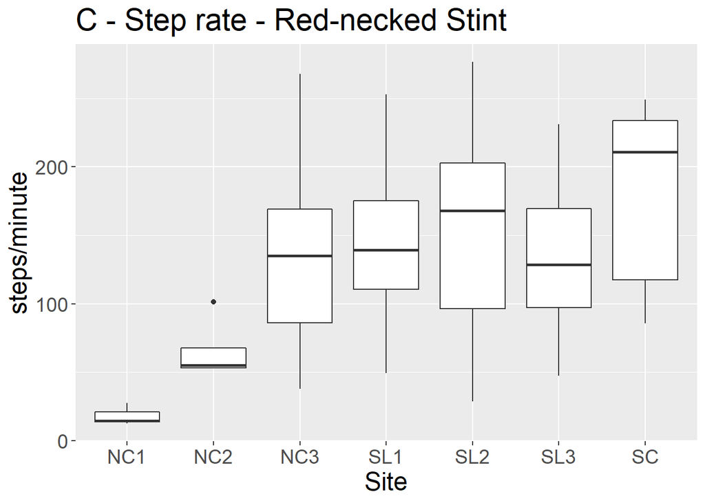

```r
ggsave("./03_plots/PPpersite_REPL.png", plot = PPpersite_REPL, width = 10, height = 5, dpi = 300)

stepspersite_REST <-
  ggplot(RESTfor, aes(x=factor(Site, level = level_order1), steprate)) +
  labs(x = "Site", y = "steps/minute") +
  theme(text = element_text(size=18)) +
  geom_boxplot() +
  ggtitle("C - Step rate - Red-necked Stint")
stepspersite_REST
```

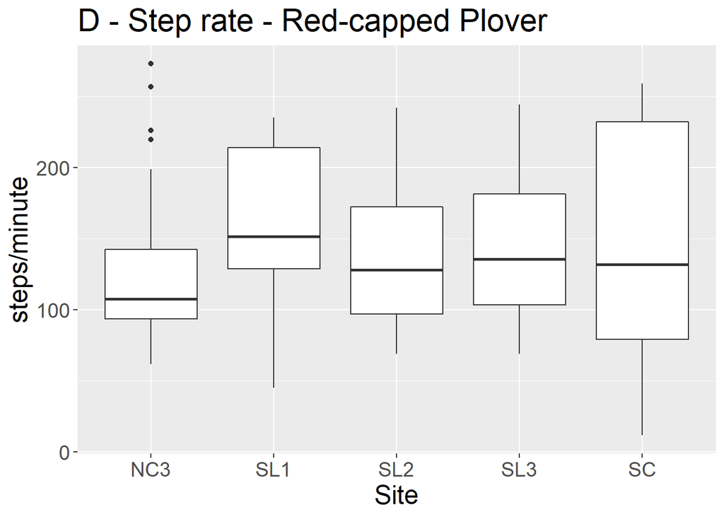

```r
ggsave("./03_plots/stepspersite_REST.png", plot = stepspersite_REST, width = 10, height = 5, dpi = 300)


stepspersite_REPL <-
  ggplot(REPLfor, aes(x=factor(Site, level = level_order1), steprate)) +
  labs(x = "Site", y = "steps/minute") +
  theme(text = element_text(size=18)) +
  geom_boxplot() +
  ggtitle("D - Step rate - Red-capped Plover")
stepspersite_REPL
```

```r
ggsave("./03_plots/stepspersite_REPL.png", plot = stepspersite_REPL, width = 10, height = 5, dpi = 300)
```

Join shorebird foraging video data with benthic and site characteristic data for modelling, make individual datasets for Red-necked Stint only and Red-capped Plover.

Create plots showing raw data of pecks + probes and steps against video length.

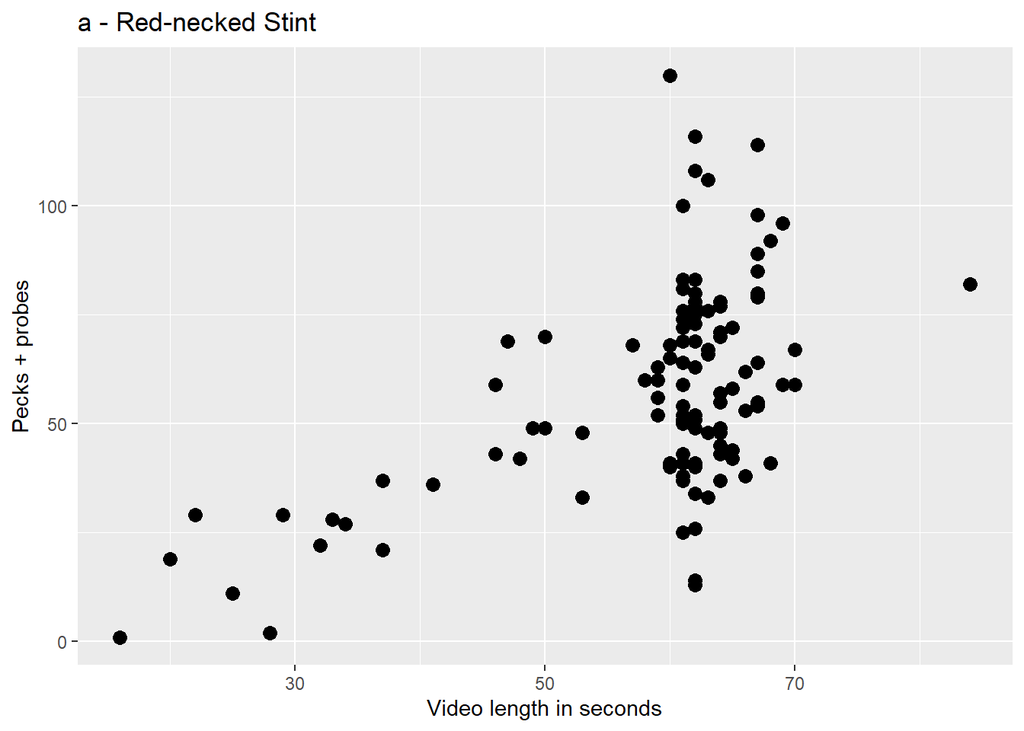

```r
sitecharben <-
  shorecountsprey %>%
  select(Date, Site, Winddirection, Windspeed, Salinity,
         MudflatAreaM, ShallowAreaha, mudshal, avgsal, avgmudshal,
         Salinity.c, Mudshal.c, avgprey, prey.c,
         tod, month, siteTOD, siteMonth, todMonth, siteTODMonth)

peckstepmod <-
  left_join(shfor, sitecharben)

peckstepmod_REST <-
  peckstepmod %>%
  filter(Species=="REST")

peckstepmod_REPL <-
  peckstepmod %>%
  filter(Species=="REPL")

plotRESTpecksprobes <- ggplot(peckstepmod_REST, aes(x = Time_sec, y = peckprobe)) +
  geom_point(size = 3) +
  labs(x = "Video length in seconds",
       y = "Pecks + probes") +
  ggtitle("a - Red-necked Stint")
plotRESTpecksprobes
```

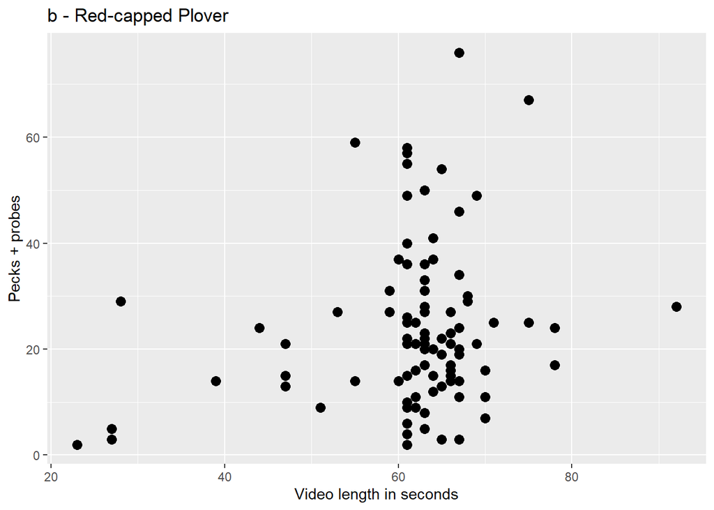

```r
ggsave("./03_plots/plotRESTpecksprobes.png", plot = plotRESTpecksprobes, width = 5, height = 3, dpi = 300)

plotREPLpecksprobes <- ggplot(peckstepmod_REPL, aes(x = Time_sec, y = peckprobe)) +
  geom_point(size = 3) +
  labs(x = "Video length in seconds",
       y = "Pecks + probes") +
  ggtitle("b - Red-capped Plover")
plotREPLpecksprobes
```

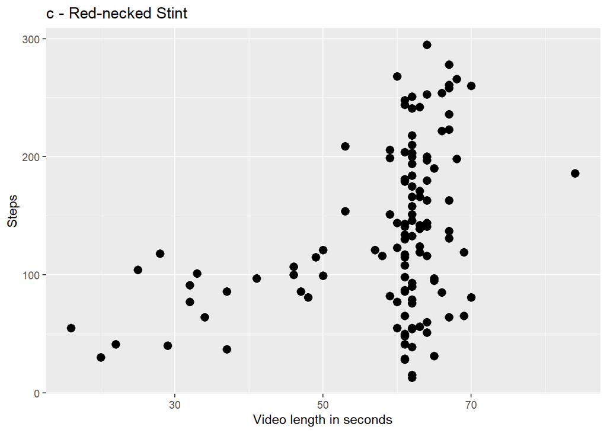

```r
ggsave("./03_plots/plotREPLpecksprobes.png", plot = plotREPLpecksprobes, width = 5, height = 3, dpi = 300)

plotRESTsteps <- ggplot(peckstepmod_REST, aes(x = Time_sec, y = Steps)) +
  geom_point(size = 3) +
  labs(x = "Video length in seconds",
       y = "Steps") +
  ggtitle("c - Red-necked Stint")
plotRESTsteps
```

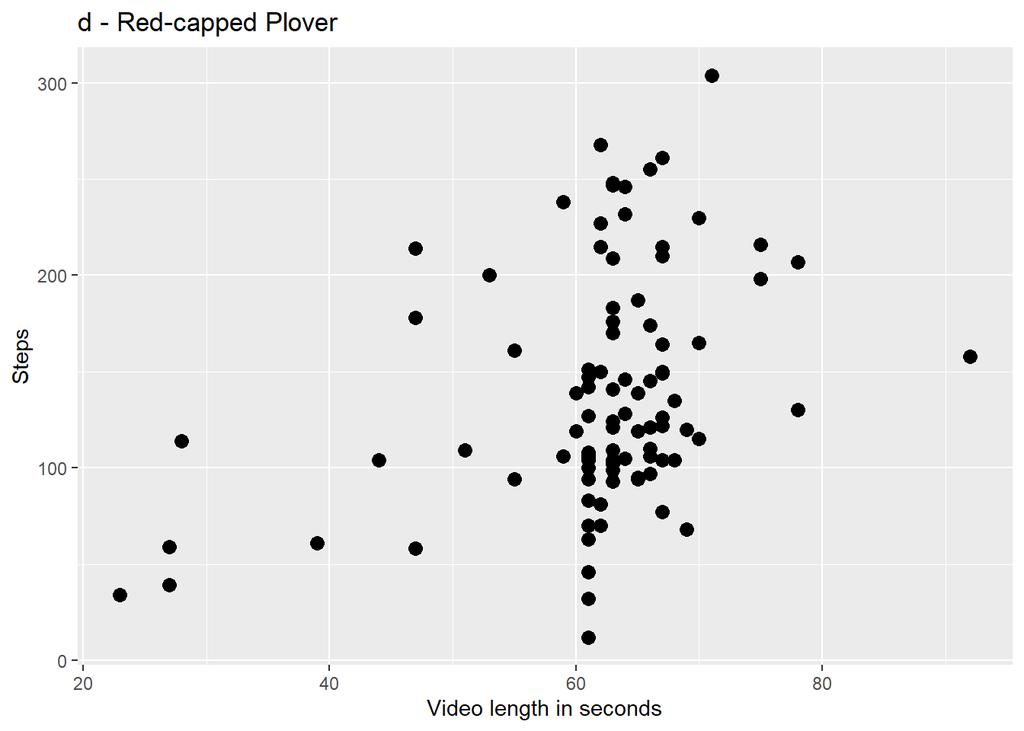

```r
ggsave("./03_plots/plotRESTsteps.png", plot = plotRESTsteps, width = 5, height = 3, dpi = 300)

plotREPLsteps <- ggplot(peckstepmod_REPL, aes(x = Time_sec, y = Steps)) +
  geom_point(size = 3) +
  labs(x = "Video length in seconds",
       y = "Steps") +
  ggtitle("d - Red-capped Plover")
plotREPLsteps
```

```r
ggsave("./03_plots/plotREPLsteps.png", plot = plotREPLsteps, width = 5, height = 3, dpi = 300)
```

Remove records where mudflat area = NA.

Model pecks + probes and steps for Red-necked Stint and Red-capped Plover.

```r
peckstepmod_REST <-
  peckstepmod_REST %>%
  filter(!is.na(MudflatAreaM))

peckstepmod_REPL <-
  peckstepmod_REPL %>%
  filter(!is.na(MudflatAreaM))


glmmpp_REST.null <- glmmTMB(peckprobe ~ 1 + (1|Site) + (1|month), data = peckstepmod_REST, family = 'nbinom2', offset = log(Time_sec/60))

glmmpp_REST.tod <- glmmTMB(peckprobe ~ as.factor(tod) + (1|Site) + (1|month), data = peckstepmod_REST, family = 'nbinom2', offset = log(Time_sec/60))

glmmpp_REST.sal <- glmmTMB(peckprobe ~ avgsal + (1|Site) + (1|month), data = peckstepmod_REST, family = 'nbinom2', offset = log(Time_sec/60))

glmmpp_REST.salC <- glmmTMB(peckprobe ~ Salinity.c + (1|Site) + (1|month), data = peckstepmod_REST, family = 'nbinom2', offset = log(Time_sec/60))

glmmpp_REST.sal2 <- glmmTMB(peckprobe ~ avgsal + Salinity.c + (1|Site) + (1|month), data = peckstepmod_REST, family = 'nbinom2', offset = log(Time_sec/60))

glmmpp_REST.prey <- glmmTMB(peckprobe ~ avgprey + (1|Site) + (1|month), data = peckstepmod_REST, family = 'nbinom2', offset = log(Time_sec/60))

glmmpp_REST.preyC <- glmmTMB(peckprobe ~ prey.c + (1|Site) + (1|month), data = peckstepmod_REST, family = 'nbinom2', offset = log(Time_sec/60))

glmmpp_REST.prey2 <- glmmTMB(peckprobe ~ avgprey + prey.c + (1|Site) + (1|month), data = peckstepmod_REST, family = 'nbinom2', offset = log(Time_sec/60))

glmmpp_REST.windD <- glmmTMB(peckprobe ~ Winddirection + (1|Site) + (1|month), data = peckstepmod_REST, family = 'nbinom2', offset = log(Time_sec/60))

glmmpp_REST.windS <- glmmTMB(peckprobe ~ Windspeed + (1|Site) + (1|month), data = peckstepmod_REST, family = 'nbinom2', offset = log(Time_sec/60))

## Model selection
AICtableREST_pp <-
AICctab(glmmpp_REST.null, glmmpp_REST.tod,
        glmmpp_REST.sal, glmmpp_REST.salC, glmmpp_REST.sal2,
        glmmpp_REST.prey, glmmpp_REST.preyC, glmmpp_REST.prey2,
        glmmpp_REST.windD, glmmpp_REST.windS,
        base = TRUE, weights = TRUE)
print(AICtableREST_pp)
```

```
##                   AICc   dAICc  df weight
## glmmpp_REST.windD 1011.2    0.0 5  0.265
## glmmpp_REST.salC  1011.9    0.7 5  0.185
## glmmpp_REST.null  1012.7    1.5 4  0.125
## glmmpp_REST.sal   1013.0    1.8 5  0.110
## glmmpp_REST.preyC 1013.2    2.0 5  0.096
## glmmpp_REST.sal2  1013.3    2.1 6  0.093
## glmmpp_REST.windS 1013.5    2.3 5  0.085
## glmmpp_REST.tod   1014.9    3.7 5  0.042
## glmmpp_REST.prey      NA     NA 5  NA
## glmmpp_REST.prey2     NA     NA 6  NA
```

```r
tab_df(AICtableREST_pp, file='./04_outputs/AICtableREST_pp.doc')
```

| AICc | dAICc | df | weight |
| --- | --- | --- | --- |
| 1011.22 | 0.00 | 5 | 0.26 |
| 1011.93 | 0.72 | 5 | 0.19 |
| 1012.72 | 1.51 | 4 | 0.12 |
| 1012.98 | 1.77 | 5 | 0.11 |
| 1013.25 | 2.03 | 5 | 0.10 |
| 1013.31 | 2.10 | 6 | 0.09 |
| 1013.50 | 2.28 | 5 | 0.08 |
| 1014.90 | 3.68 | 5 | 0.04 |
| NA | NA | 5 | NA |
| NA | NA | 6 | NA |

```r
write.csv(AICtableREST_pp, './04_outputs/AICtableREST_pp.csv')

glmmstep_REST.null <- glmmTMB(Steps ~ 1 + (1|Site) + (1|month), data = peckstepmod_REST, family = 'nbinom2', offset = log(Time_sec/60))

glmmstep_REST.tod <- glmmTMB(Steps ~ as.factor(tod) + (1|Site) + (1|month), data = peckstepmod_REST, family = 'nbinom2', offset = log(Time_sec/60))

glmmstep_REST.sal <- glmmTMB(Steps ~ avgsal + (1|Site) + (1|month), data = peckstepmod_REST, family = 'nbinom2', offset = log(Time_sec/60))

glmmstep_REST.salC <- glmmTMB(Steps ~ Salinity.c + (1|Site) + (1|month), data = peckstepmod_REST, family = 'nbinom2', offset = log(Time_sec/60))

glmmstep_REST.sal2 <- glmmTMB(Steps ~ avgsal + Salinity.c + (1|Site) + (1|month), data = peckstepmod_REST, family = 'nbinom2', offset = log(Time_sec/60))

glmmstep_REST.prey <- glmmTMB(Steps ~ avgprey + (1|Site) + (1|month), data = peckstepmod_REST, family = 'nbinom2', offset = log(Time_sec/60))

glmmstep_REST.preyC <- glmmTMB(Steps ~ prey.c + (1|Site) + (1|month), data = peckstepmod_REST, family = 'nbinom2', offset = log(Time_sec/60))

glmmstep_REST.prey2 <- glmmTMB(Steps ~ avgprey + prey.c + (1|Site) + (1|month), data = peckstepmod_REST, family = 'nbinom2', offset = log(Time_sec/60))

glmmstep_REST.windD <- glmmTMB(Steps ~ Winddirection + (1|Site) + (1|month), data = peckstepmod_REST, family = 'nbinom2', offset = log(Time_sec/60))

glmmstep_REST.windS <- glmmTMB(Steps ~ Windspeed + (1|Site) + (1|month), data = peckstepmod_REST, family = 'nbinom2', offset = log(Time_sec/60))

## Model selection
AICtableREST_step <-
AICctab(glmmstep_REST.null, glmmstep_REST.tod,
        glmmstep_REST.sal, glmmstep_REST.salC, glmmstep_REST.sal2,
        glmmstep_REST.prey, glmmstep_REST.preyC, glmmstep_REST.prey2,
        glmmstep_REST.windD, glmmstep_REST.windS,
        base = TRUE, weights = TRUE)
print(AICtableREST_step)
```

```
##                     AICc   dAICc  df weight
## glmmstep_REST.prey2 1240.6    0.0 6  0.8842
## glmmstep_REST.prey  1244.7    4.1 5  0.1132
## glmmstep_REST.sal   1253.0   12.4 5  0.0018
## glmmstep_REST.sal2  1255.2   14.6 6  <0.001
## glmmstep_REST.null  1260.0   19.4 4  <0.001
## glmmstep_REST.preyC 1260.4   19.8 5  <0.001
## glmmstep_REST.tod   1261.7   21.1 5  <0.001
## glmmstep_REST.windS 1262.2   21.6 5  <0.001
## glmmstep_REST.salC  1262.2   21.6 5  <0.001
## glmmstep_REST.windD 1262.2   21.6 5  <0.001
```

```r
tab_df(AICtableREST_step, file='./04_outputs/AICtableREST_step.doc')
```

| AICc | dAICc | df | weight |
| --- | --- | --- | --- |
| 1240.60 | 0.00 | 6 | 0.88 |
| 1244.71 | 4.11 | 5 | 0.11 |
| 1252.98 | 12.38 | 5 | 0.00 |
| 1255.17 | 14.57 | 6 | 0.00 |
| 1260.03 | 19.44 | 4 | 0.00 |
| 1260.37 | 19.77 | 5 | 0.00 |
| 1261.73 | 21.14 | 5 | 0.00 |
| 1262.16 | 21.57 | 5 | 0.00 |
| 1262.20 | 21.60 | 5 | 0.00 |
| 1262.22 | 21.62 | 5 | 0.00 |

```r
write.csv(AICtableREST_step, './04_outputs/AICtableREST_step.csv')

glmmpp_REPL.null <- glmmTMB(peckprobe ~ 1 + (1|Site) + (1|month), data = peckstepmod_REPL, family = 'nbinom2', offset = log(Time_sec/60))

glmmpp_REPL.tod <- glmmTMB(peckprobe ~ as.factor(tod) + (1|Site) + (1|month), data = peckstepmod_REPL, family = 'nbinom2', offset = log(Time_sec/60))

glmmpp_REPL.sal <- glmmTMB(peckprobe ~ avgsal + (1|Site) + (1|month), data = peckstepmod_REPL, family = 'nbinom2', offset = log(Time_sec/60))

glmmpp_REPL.salC <- glmmTMB(peckprobe ~ Salinity.c + (1|Site) + (1|month), data = peckstepmod_REPL, family = 'nbinom2', offset = log(Time_sec/60))

glmmpp_REPL.sal2 <- glmmTMB(peckprobe ~ avgsal + Salinity.c + (1|Site) + (1|month), data = peckstepmod_REPL, family = 'nbinom2', offset = log(Time_sec/60))

glmmpp_REPL.prey <- glmmTMB(peckprobe ~ avgprey + (1|Site) + (1|month), data = peckstepmod_REPL, family = 'nbinom2', offset = log(Time_sec/60))

glmmpp_REPL.preyC <- glmmTMB(peckprobe ~ prey.c + (1|Site) + (1|month), data = peckstepmod_REPL, family = 'nbinom2', offset = log(Time_sec/60))

glmmpp_REPL.prey2 <- glmmTMB(peckprobe ~ avgprey + prey.c + (1|Site) + (1|month), data = peckstepmod_REPL, family = 'nbinom2', offset = log(Time_sec/60))

glmmpp_REPL.windD <- glmmTMB(peckprobe ~ Winddirection + (1|Site) + (1|month), data = peckstepmod_REPL, family = 'nbinom2', offset = log(Time_sec/60))

glmmpp_REPL.windS <- glmmTMB(peckprobe ~ Windspeed + (1|Site) + (1|month), data = peckstepmod_REPL, family = 'nbinom2', offset = log(Time_sec/60))

## Model selection
AICtableREPL_pp <-
AICctab(glmmpp_REPL.null, glmmpp_REPL.tod,
        glmmpp_REPL.sal, glmmpp_REPL.salC, glmmpp_REPL.sal2,
        glmmpp_REPL.prey, glmmpp_REPL.preyC, glmmpp_REPL.prey2,
        glmmpp_REPL.windD, glmmpp_REPL.windS,
        base = TRUE, weights = TRUE)
print(AICtableREPL_pp)
```

```
##                   AICc  dAICc df weight
## glmmpp_REPL.windD 736.4   0.0 5  0.273
## glmmpp_REPL.null  737.2   0.8 4  0.185
## glmmpp_REPL.sal   738.2   1.7 5  0.114
## glmmpp_REPL.preyC 738.6   2.2 5  0.092
## glmmpp_REPL.prey  739.0   2.6 5  0.074
## glmmpp_REPL.salC  739.4   2.9 5  0.063
## glmmpp_REPL.windS 739.4   3.0 5  0.062
## glmmpp_REPL.tod   739.4   3.0 5  0.061
## glmmpp_REPL.prey2 740.3   3.9 6  0.040
## glmmpp_REPL.sal2  740.5   4.0 6  0.036
```

```r
tab_df(AICtableREPL_pp, file='./04_outputs/AICtableREPL_pp.doc')
```

| AICc | dAICc | df | weight |
| --- | --- | --- | --- |
| 736.43 | 0.00 | 5 | 0.27 |
| 737.21 | 0.77 | 4 | 0.19 |
| 738.18 | 1.75 | 5 | 0.11 |
| 738.61 | 2.17 | 5 | 0.09 |
| 739.03 | 2.60 | 5 | 0.07 |
| 739.35 | 2.92 | 5 | 0.06 |
| 739.41 | 2.98 | 5 | 0.06 |
| 739.44 | 3.00 | 5 | 0.06 |
| 740.29 | 3.86 | 6 | 0.04 |
| 740.47 | 4.03 | 6 | 0.04 |

```r
write.csv(AICtableREPL_pp, './04_outputs/AICtableREPL_pp.csv')

glmmstep_REPL.null <- glmmTMB(Steps ~ 1 + (1|Site) + (1|month), data = peckstepmod_REPL, family = 'nbinom2', offset = log(Time_sec/60))

glmmstep_REPL.tod <- glmmTMB(Steps ~ as.factor(tod) + (1|Site) + (1|month), data = peckstepmod_REPL, family = 'nbinom2', offset = log(Time_sec/60))

glmmstep_REPL.sal <- glmmTMB(Steps ~ avgsal + (1|Site) + (1|month), data = peckstepmod_REPL, family = 'nbinom2', offset = log(Time_sec/60))

glmmstep_REPL.salC <- glmmTMB(Steps ~ Salinity.c + (1|Site) + (1|month), data = peckstepmod_REPL, family = 'nbinom2', offset = log(Time_sec/60))

glmmstep_REPL.sal2 <- glmmTMB(Steps ~ avgsal + Salinity.c + (1|Site) + (1|month), data = peckstepmod_REPL, family = 'nbinom2', offset = log(Time_sec/60))

glmmstep_REPL.prey <- glmmTMB(Steps ~ avgprey + (1|Site) + (1|month), data = peckstepmod_REPL, family = 'nbinom2', offset = log(Time_sec/60))

glmmstep_REPL.preyC <- glmmTMB(Steps ~ prey.c + (1|Site) + (1|month), data = peckstepmod_REPL, family = 'nbinom2', offset = log(Time_sec/60))

glmmstep_REPL.prey2 <- glmmTMB(Steps ~ avgprey + prey.c + (1|Site) + (1|month), data = peckstepmod_REPL, family = 'nbinom2', offset = log(Time_sec/60))

glmmstep_REPL.windD <- glmmTMB(Steps ~ Winddirection + (1|Site) + (1|month), data = peckstepmod_REPL, family = 'nbinom2', offset = log(Time_sec/60))

glmmstep_REPL.windS <- glmmTMB(Steps ~ Windspeed + (1|Site) + (1|month), data = peckstepmod_REPL, family = 'nbinom2', offset = log(Time_sec/60))

## Model selection
AICtableREPL_step <-
AICctab(glmmstep_REPL.null, glmmstep_REPL.tod,
        glmmstep_REPL.sal, glmmstep_REPL.salC, glmmstep_REPL.sal2,
        glmmstep_REPL.prey, glmmstep_REPL.preyC, glmmstep_REPL.prey2,
        glmmstep_REPL.windD, glmmstep_REPL.windS,
        base = TRUE, weights = TRUE)
print(AICtableREPL_step)
```

```
##                     AICc  dAICc df weight
## glmmstep_REPL.preyC 989.3   0.0 5  0.630
## glmmstep_REPL.prey2 991.6   2.3 6  0.200
## glmmstep_REPL.null  994.3   5.0 4  0.051
## glmmstep_REPL.salC  995.1   5.8 5  0.034
## glmmstep_REPL.sal   996.2   6.9 5  0.020
## glmmstep_REPL.prey  996.6   7.3 5  0.017
## glmmstep_REPL.tod   996.6   7.3 5  0.017
## glmmstep_REPL.windD 996.6   7.3 5  0.017
## glmmstep_REPL.sal2  996.9   7.5 6  0.014
## glmmstep_REPL.windS    NA    NA 5  NA
```

```r
tab_df(AICtableREPL_step, file='./04_outputs/AICtableREPL_step.doc')
```

| AICc | dAICc | df | weight |
| --- | --- | --- | --- |
| 989.31 | 0.00 | 5 | 0.63 |
| 991.60 | 2.29 | 6 | 0.20 |
| 994.34 | 5.03 | 4 | 0.05 |
| 995.13 | 5.83 | 5 | 0.03 |
| 996.21 | 6.90 | 5 | 0.02 |
| 996.56 | 7.26 | 5 | 0.02 |
| 996.57 | 7.26 | 5 | 0.02 |
| 996.58 | 7.27 | 5 | 0.02 |
| 996.85 | 7.55 | 6 | 0.01 |
| NA | NA | 5 | NA |

```r
write.csv(AICtableREPL_step, './04_outputs/AICtableREPL_step.csv')
```

```r
r.squaredGLMM(glmmpp_REST.windD)
```

```
##                  R2m        R2c
## delta     0.03215605 0.03215606
## lognormal 0.03380520 0.03380520
## trigamma  0.03050443 0.03050443
```

```r
car::Anova(glmmpp_REST.windD)
```

```
## Analysis of Deviance Table (Type II Wald chisquare tests)
##
## Response: peckprobe
##                Chisq Df Pr(>Chisq)
## Winddirection 3.7925  1    0.05148 .
## ---
## Signif. codes:  0 '***' 0.001 '**' 0.01 '*' 0.05 '.' 0.1 ' ' 1
```

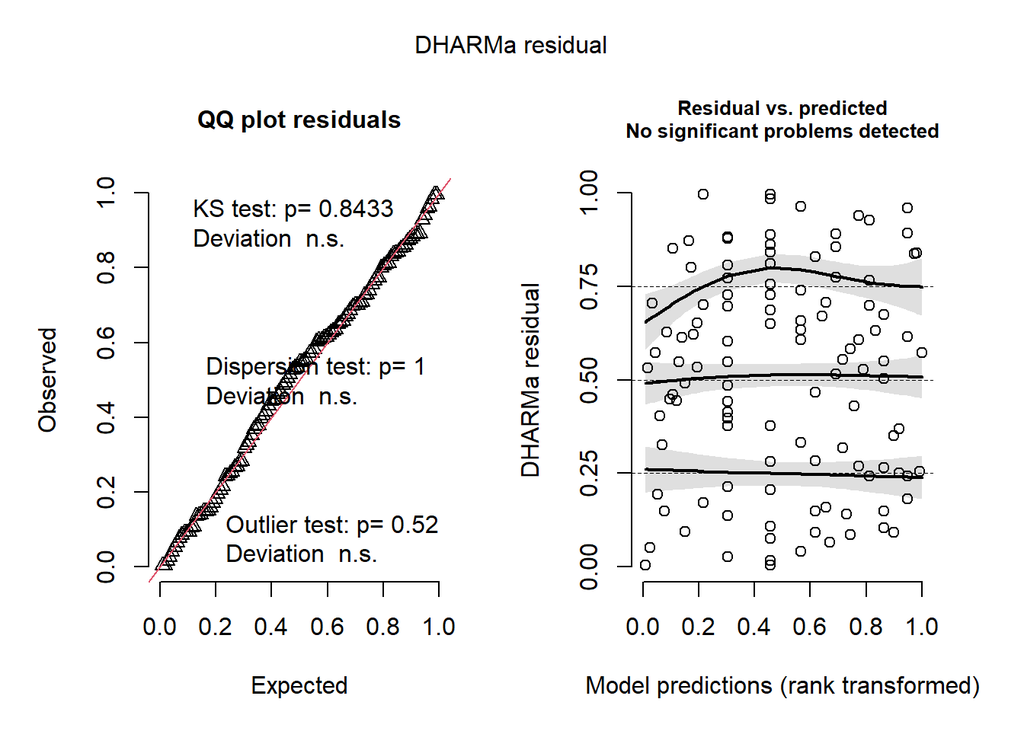

```r
plot(simres <- simulateResiduals(glmmpp_REST.windD))
```

```r
testZeroInflation(simres, plot = FALSE)
```

```
##
##  DHARMa zero-inflation test via comparison to expected zeros with
##  simulation under H0 = fitted model
##
## data:  simulationOutput
## ratioObsSim = NaN, p-value = 1
## alternative hypothesis: two.sided
```

```r
TopmodelREST_pp1 <- tidy(glmmpp_REST.windD)

tab_df(TopmodelREST_pp1, file='./04_outputs/TopmodelREST_pp1.doc')
```

| effect | component | group | term | estimate | std.error | statistic | p.value |
| --- | --- | --- | --- | --- | --- | --- | --- |
| fixed | cond | NA | (Intercept) | 4.19 | 0.06 | 75.73 | 0.00 |
| fixed | cond | NA | WinddirectionOth | -0.13 | 0.07 | -1.95 | 0.05 |
| ran_pars | cond | Site | sd__(Intercept) | 0.00 | NA | NA | NA |
| ran_pars | cond | month | sd__(Intercept) | 0.00 | NA | NA | NA |

```r
write.csv(TopmodelREST_pp1, './04_outputs/TopmodelREST_pp1.csv')

r.squaredGLMM(glmmpp_REST.salC)
```

```
##                  R2m        R2c
## delta     0.02711365 0.02711365
## lognormal 0.02851624 0.02851624
## trigamma  0.02570970 0.02570970
```

```r
car::Anova(glmmpp_REST.salC)
```

```
## Analysis of Deviance Table (Type II Wald chisquare tests)
##
## Response: peckprobe
##            Chisq Df Pr(>Chisq)
## Salinity.c 3.093  1    0.07863 .
## ---
## Signif. codes:  0 '***' 0.001 '**' 0.01 '*' 0.05 '.' 0.1 ' ' 1
```

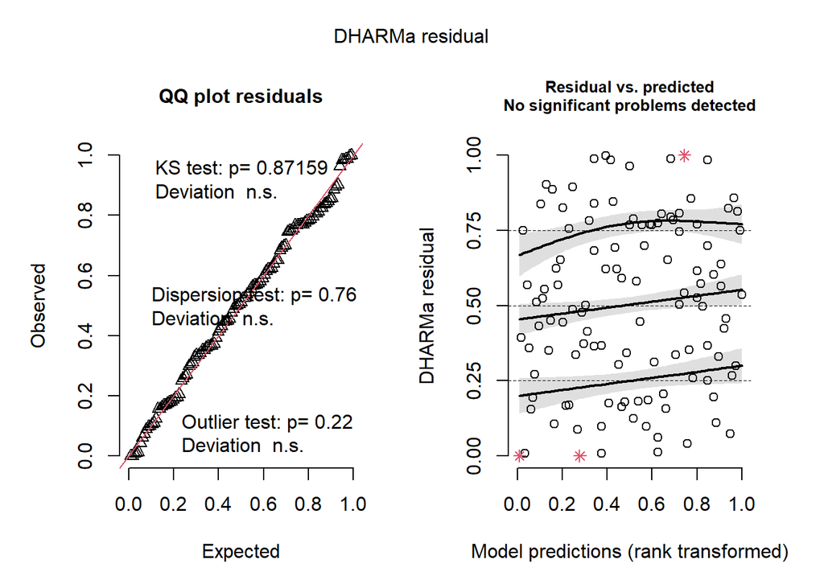

```r
plot(simres <- simulateResiduals(glmmpp_REST.salC))
```

```r
testZeroInflation(simres, plot = FALSE)
```

```
##
##  DHARMa zero-inflation test via comparison to expected zeros with
##  simulation under H0 = fitted model
##
## data:  simulationOutput
## ratioObsSim = NaN, p-value = 1
## alternative hypothesis: two.sided
```

```r
TopmodelREST_pp2 <- tidy(glmmpp_REST.salC)

tab_df(TopmodelREST_pp2, file='./04_outputs/TopmodelREST_pp2.doc')
```

| effect | component | group | term | estimate | std.error | statistic | p.value |
| --- | --- | --- | --- | --- | --- | --- | --- |
| fixed | cond | NA | (Intercept) | 4.10 | 0.03 | 132.17 | 0.00 |
| fixed | cond | NA | Salinity.c | -0.05 | 0.03 | -1.76 | 0.08 |
| ran_pars | cond | Site | sd__(Intercept) | 0.00 | NA | NA | NA |
| ran_pars | cond | month | sd__(Intercept) | 0.00 | NA | NA | NA |

```r
write.csv(TopmodelREST_pp2, './04_outputs/TopmodelREST_pp2.csv')

r.squaredGLMM(glmmpp_REST.sal)
```

```
##                  R2m        R2c
## delta     0.01634520 0.03628307
## lognormal 0.01717708 0.03812968
## trigamma  0.01551170 0.03443286
```

```r
car::Anova(glmmpp_REST.sal)
```

```
## Analysis of Deviance Table (Type II Wald chisquare tests)
##
## Response: peckprobe
##         Chisq Df Pr(>Chisq)
## avgsal 1.8887  1     0.1693
```

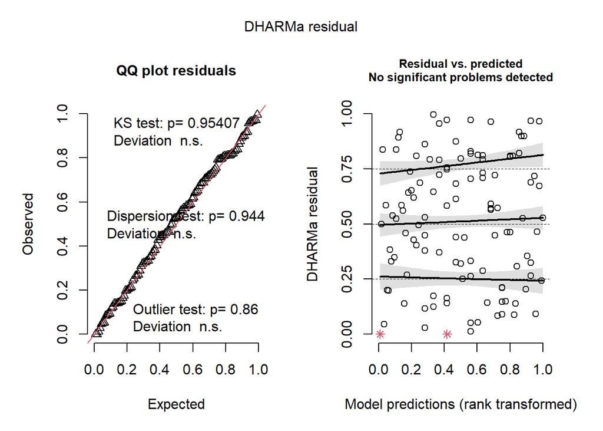

```r
plot(simres <- simulateResiduals(glmmpp_REST.sal))
```

```r
testZeroInflation(simres, plot = FALSE)
```

```
##
##  DHARMa zero-inflation test via comparison to expected zeros with
##  simulation under H0 = fitted model
##
## data:  simulationOutput
## ratioObsSim = NaN, p-value = 1
## alternative hypothesis: two.sided
```

```r
TopmodelREST_pp3 <- tidy(glmmpp_REST.sal)

tab_df(TopmodelREST_pp3, file='./04_outputs/TopmodelREST_pp3.doc')
```

| effect | component | group | term | estimate | std.error | statistic | p.value |
| --- | --- | --- | --- | --- | --- | --- | --- |
| fixed | cond | NA | (Intercept) | 4.25 | 0.12 | 35.21 | 0.00 |
| fixed | cond | NA | avgsal | -0.00 | 0.00 | -1.37 | 0.17 |
| ran_pars | cond | Site | sd__(Intercept) | 0.00 | NA | NA | NA |
| ran_pars | cond | month | sd__(Intercept) | 0.05 | NA | NA | NA |

```r
write.csv(TopmodelREST_pp3, './04_outputs/TopmodelREST_pp3.csv')

r.squaredGLMM(glmmstep_REST.prey2)
```

```
##                 R2m       R2c
## delta     0.4032933 0.5113605
## lognormal 0.4182940 0.5303809
## trigamma  0.3870984 0.4908260
```

```r
car::Anova(glmmstep_REST.prey2)
```

```
## Analysis of Deviance Table (Type II Wald chisquare tests)
##
## Response: Steps
##           Chisq Df        Pr(>Chisq)
## avgprey 50.2191  1 0.000000000001375 ***
## prey.c   8.1519  1          0.004302 **
## ---
## Signif. codes:  0 '***' 0.001 '**' 0.01 '*' 0.05 '.' 0.1 ' ' 1
```

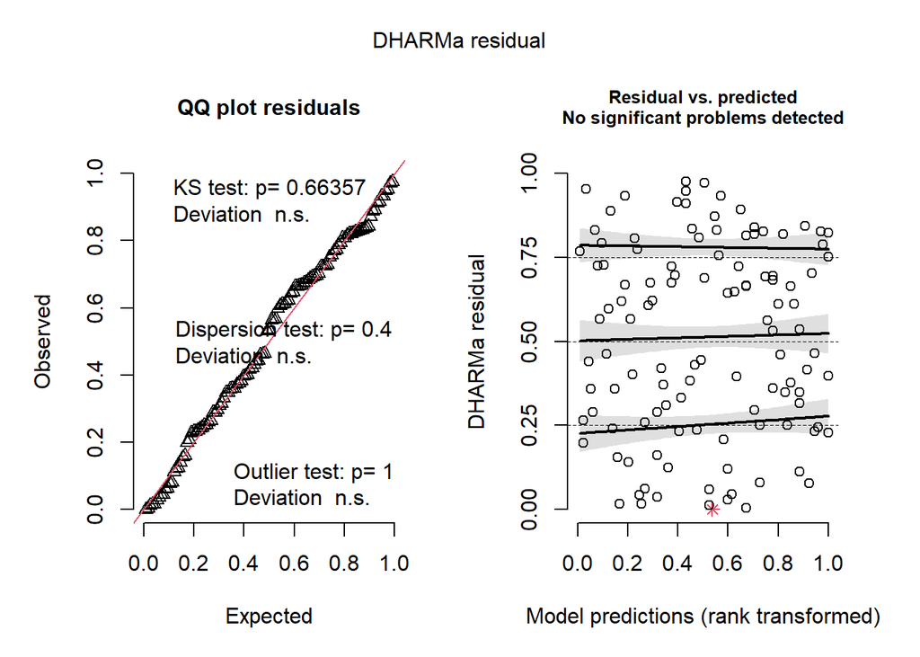

```r
plot(simres <- simulateResiduals(glmmstep_REST.prey2))
```

```r
testZeroInflation(simres, plot = FALSE)
```

```
##
##  DHARMa zero-inflation test via comparison to expected zeros with
##  simulation under H0 = fitted model
##
## data:  simulationOutput
## ratioObsSim = NaN, p-value = 1
## alternative hypothesis: two.sided
```

```r
TopmodelREST_step <- tidy(glmmstep_REST.prey2)

tab_df(TopmodelREST_step, file='./04_outputs/TopmodelREST_step.doc')
```

| effect | component | group | term | estimate | std.error | statistic | p.value |
| --- | --- | --- | --- | --- | --- | --- | --- |
| fixed | cond | NA | (Intercept) | 5.45 | 0.12 | 45.54 | 0.00 |
| fixed | cond | NA | avgprey | -0.49 | 0.07 | -7.09 | 0.00 |
| fixed | cond | NA | prey.c | -0.17 | 0.06 | -2.86 | 0.00 |
| ran_pars | cond | Site | sd__(Intercept) | 0.03 | NA | NA | NA |
| ran_pars | cond | month | sd__(Intercept) | 0.19 | NA | NA | NA |

```r
write.csv(TopmodelREST_step, './04_outputs/TopmodelREST_step.csv')

r.squaredGLMM(glmmpp_REPL.windD)
```

```
##                  R2m        R2c
## delta     0.03562790 0.07065796
## lognormal 0.04088540 0.08108473
## trigamma  0.03034479 0.06018040
```

```r
car::Anova(glmmpp_REPL.windD)
```

```
## Analysis of Deviance Table (Type II Wald chisquare tests)
##
## Response: peckprobe
##                Chisq Df Pr(>Chisq)
## Winddirection 3.0005  1    0.08324 .
## ---
## Signif. codes:  0 '***' 0.001 '**' 0.01 '*' 0.05 '.' 0.1 ' ' 1
```

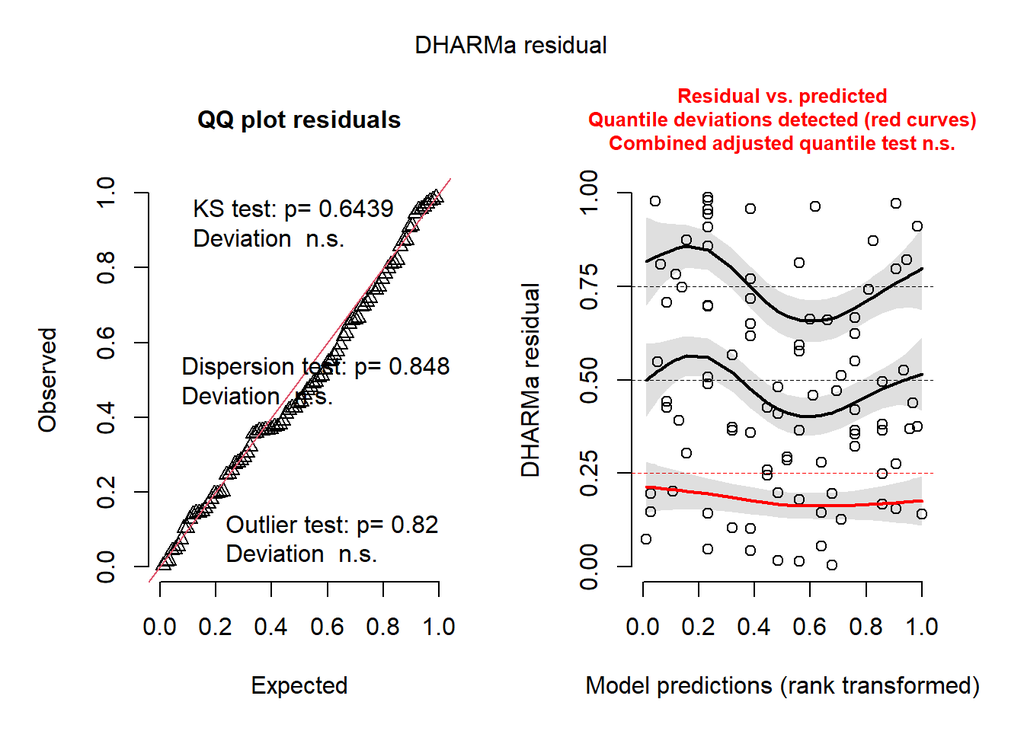

```r
plot(simres <- simulateResiduals(glmmpp_REPL.windD))
```

```r
testZeroInflation(simres, plot = FALSE)
```

```
##
##  DHARMa zero-inflation test via comparison to expected zeros with
##  simulation under H0 = fitted model
##
## data:  simulationOutput
## ratioObsSim = 0, p-value = 1
## alternative hypothesis: two.sided
```

```r
TopmodelREPL_pp1 <- tidy(glmmpp_REPL.windD)

tab_df(TopmodelREPL_pp1, file='./04_outputs/TopmodelREPL_pp1.doc')
```

| effect | component | group | term | estimate | std.error | statistic | p.value |
| --- | --- | --- | --- | --- | --- | --- | --- |
| fixed | cond | NA | (Intercept) | 3.34 | 0.12 | 27.58 | 0.00 |
| fixed | cond | NA | WinddirectionOth | -0.24 | 0.14 | -1.73 | 0.08 |
| ran_pars | cond | Site | sd__(Intercept) | 0.11 | NA | NA | NA |
| ran_pars | cond | month | sd__(Intercept) | 0.00 | NA | NA | NA |

```r
write.csv(TopmodelREPL_pp1, './04_outputs/TopmodelREPL_pp1.csv')

r.squaredGLMM(glmmpp_REPL.salC)
```

```
##                    R2m        R2c
## delta     0.0010734708 0.04286652
## lognormal 0.0012419464 0.04959420
## trigamma  0.0009057712 0.03616983
```

```r
car::Anova(glmmpp_REPL.salC)
```

```
## Analysis of Deviance Table (Type II Wald chisquare tests)
##
## Response: peckprobe
##             Chisq Df Pr(>Chisq)
## Salinity.c 0.0912  1     0.7626
```

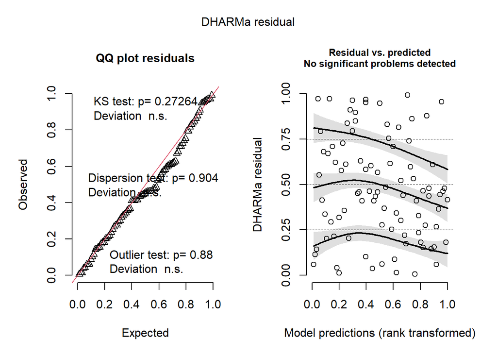

```r
plot(simres <- simulateResiduals(glmmpp_REPL.salC))
```

```r
testZeroInflation(simres, plot = FALSE)
```

```
##
##  DHARMa zero-inflation test via comparison to expected zeros with
##  simulation under H0 = fitted model
##
## data:  simulationOutput
## ratioObsSim = 0, p-value = 1
## alternative hypothesis: two.sided
```

```r
TopmodelREPL_pp2 <- tidy(glmmpp_REPL.salC)

tab_df(TopmodelREPL_pp2, file='./04_outputs/TopmodelREPL_pp2.doc')
```

| effect | component | group | term | estimate | std.error | statistic | p.value |
| --- | --- | --- | --- | --- | --- | --- | --- |
| fixed | cond | NA | (Intercept) | 3.20 | 0.09 | 34.53 | 0.00 |
| fixed | cond | NA | Salinity.c | 0.02 | 0.07 | 0.30 | 0.76 |
| ran_pars | cond | Site | sd__(Intercept) | 0.12 | NA | NA | NA |
| ran_pars | cond | month | sd__(Intercept) | 0.00 | NA | NA | NA |

```r
write.csv(TopmodelREPL_pp2, './04_outputs/TopmodelREPL_pp2.csv')

r.squaredGLMM(glmmstep_REPL.preyC)
```

```
##                  R2m       R2c
## delta     0.08906930 0.4501690
## lognormal 0.09197766 0.4648683
## trigamma  0.08600461 0.4346797
```

```r
car::Anova(glmmstep_REPL.preyC)
```

```
## Analysis of Deviance Table (Type II Wald chisquare tests)
##
## Response: Steps
##         Chisq Df Pr(>Chisq)
## prey.c 7.7267  1   0.005441 **
## ---
## Signif. codes:  0 '***' 0.001 '**' 0.01 '*' 0.05 '.' 0.1 ' ' 1
```

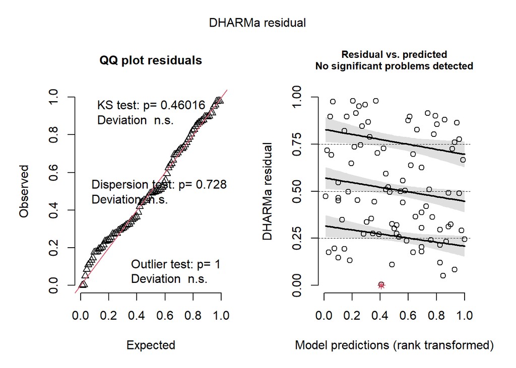

```r
plot(simres <- simulateResiduals(glmmstep_REPL.preyC))
```

```r
testZeroInflation(simres, plot = FALSE)
```

```
##
##  DHARMa zero-inflation test via comparison to expected zeros with
##  simulation under H0 = fitted model
##
## data:  simulationOutput
## ratioObsSim = NaN, p-value = 1
## alternative hypothesis: two.sided
```

```r
TopmodelREPL_step <- tidy(glmmstep_REPL.preyC)

tab_df(TopmodelREPL_step, file='./04_outputs/TopmodelREPL_step.doc')
```

| effect | component | group | term | estimate | std.error | statistic | p.value |
| --- | --- | --- | --- | --- | --- | --- | --- |
| fixed | cond | NA | (Intercept) | 4.86 | 0.12 | 42.20 | 0.00 |
| fixed | cond | NA | prey.c | -0.14 | 0.05 | -2.78 | 0.01 |
| ran_pars | cond | Site | sd__(Intercept) | 0.00 | NA | NA | NA |
| ran_pars | cond | month | sd__(Intercept) | 0.29 | NA | NA | NA |

```r
write.csv(TopmodelREPL_step, './04_outputs/TopmodelREPL_step.csv')
```

Obtain and plot predicted values of the top model for Red-necked Stint and Red-capped Plover step rate.

Set up dataframe for predictions. Vary a single parameter while setting the rest at their mean values. Choose a level for factor variables and select a value for any random effect so all variables used for fitting the model are represented.

Retrieve a function to back-convert from the link to the response scale, in this case exp because nbinom has a log link.

Make predictions, on the link scale, setting all random effects to zero, then back-transform.

Plot the responses.

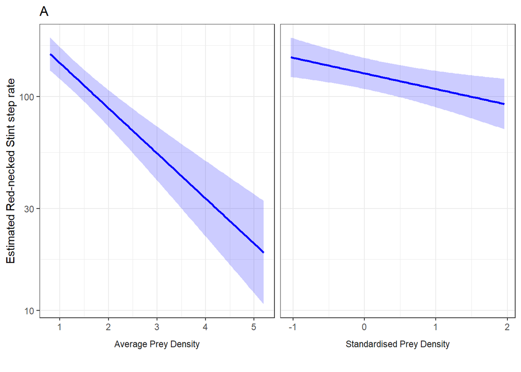

```r
new_stepdataREST <- data.frame(avgprey=mean(peckstepmod_REST$avgprey),
                       prey.c=mean(peckstepmod_REST$prey.c),
                       Site=peckstepmod_REST$Site[1], month=peckstepmod_REST$month[1],
                       Time_sec=mean(peckstepmod_REST$Time_sec))
new_stepdataREST1 <- new_stepdataREST2 <- new_stepdataREST[rep(1,100),]
new_stepdataREST1$avgprey <- seq(min(peckstepmod_REST$avgprey), max(peckstepmod_REST$avgprey), length.out=100)
new_stepdataREST1$x <- new_stepdataREST1$avgprey
new_stepdataREST1$Variable <- 'Average Prey Density'
new_stepdataREST2$prey.c <- seq(min(peckstepmod_REST$prey.c), max(peckstepmod_REST$prey.c), length.out=100)
new_stepdataREST2$Variable <- 'Standardised Prey Density'
new_stepdataREST2$x <- new_stepdataREST2$prey.c
new_stepdataREST <- rbind(new_stepdataREST1, new_stepdataREST2)

ilink_RESTstep <- family(glmmstep_REST.prey2)$linkinv

pred_RESTstep <- predict(glmmstep_REST.prey2, new_stepdataREST, type = "link", se.fit = TRUE, re.form=~0)
pred_RESTstep <- cbind(pred_RESTstep, new_stepdataREST)

pred_RESTstep <- transform(pred_RESTstep, lwr_ci = ilink_RESTstep(fit - (1.96* se.fit)),
                  upr_ci = ilink_RESTstep(fit + (1.96 * se.fit)),
                  fitted = ilink_RESTstep(fit))

predicted_RESTstep <- ggplot(pred_RESTstep, aes(x, fitted)) +
  geom_ribbon(aes(ymin=lwr_ci, ymax=upr_ci), fill='blue', alpha=0.2, ) +
  geom_line(colour='blue', size=1) +
  scale_y_log10() +
  facet_grid(~Variable, scales='free_x', switch='x') +
  ggtitle("A") +
  xlab('') +
  ylab('Estimated Red-necked Stint step rate') + theme_bw() +
  theme(strip.placement='outside',strip.background = element_blank())

predicted_RESTstep
```

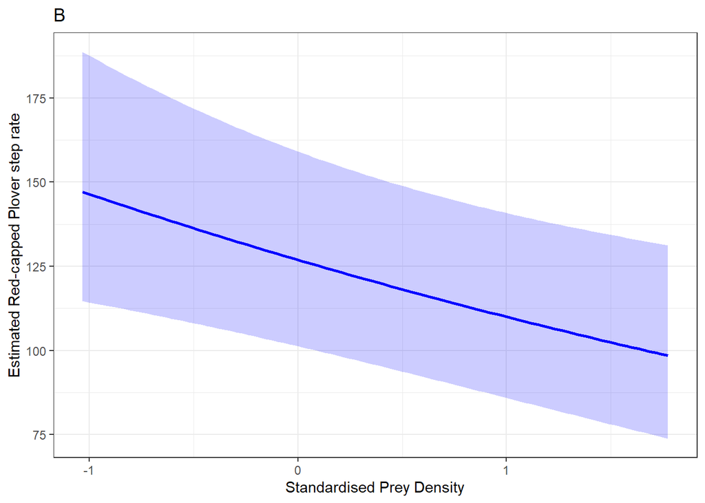

```r
ggsave("./03_plots/predicted_RESTstep.png", plot = predicted_RESTstep, width = 8, height = 5, dpi = 300)

new_stepdataREPL <- data.frame(prey.c=mean(peckstepmod_REPL$prey.c),
                       Site=peckstepmod_REPL$Site[1], month=peckstepmod_REPL$month[1],
                       Time_sec=mean(peckstepmod_REPL$Time_sec))
new_stepdataREPL1 <- new_stepdataREST[rep(1,100),]
new_stepdataREPL1$prey.c <- seq(min(peckstepmod_REPL$prey.c), max(peckstepmod_REPL$prey.c), length.out=100)
new_stepdataREPL1$Variable <- 'Standardised Prey Density'
new_stepdataREPL1$x <- new_stepdataREPL1$prey.c
new_stepdataREPL <- new_stepdataREPL1

ilink_REPLstep <- family(glmmstep_REPL.preyC)$linkinv

pred_REPLstep <- predict(glmmstep_REPL.preyC, new_stepdataREPL, type = "link", se.fit = TRUE, re.form=~0)
pred_REPLstep <- cbind(pred_REPLstep, new_stepdataREPL)

pred_REPLstep <- transform(pred_REPLstep, lwr_ci = ilink_REPLstep(fit - (1.96* se.fit)),
                  upr_ci = ilink_REPLstep(fit + (1.96 * se.fit)),
                  fitted = ilink_REPLstep(fit))

predicted_REPLstep <- ggplot(pred_REPLstep, aes(x, fitted)) +
  geom_ribbon(aes(ymin=lwr_ci, ymax=upr_ci), fill='blue', alpha=0.2, ) +
  geom_line(colour='blue', size=1) +
  scale_y_continuous() +
  ggtitle("B") +
  xlab('Standardised Prey Density') +
  ylab('Estimated Red-capped Plover step rate') + theme_bw() +
  theme(strip.placement='outside',strip.background = element_blank())

predicted_REPLstep
```

```r
ggsave("./03_plots/predicted_REPLstep.png", plot = predicted_REPLstep, width = 5, height = 5, dpi = 300)
```